# 分析模式：可重用对象模型

#### 5.3 对象合并

#### 5.3 Object Merge

我们喜欢把事物想象成某种完整的存在：一旦被识别，它就永远被识别了。然而，现实生活远比这复杂。想象一下，一位病人来到医院接受治疗。几天后，他们发现这位病人同时也是医院另一个科室的门诊病人。但是，医院的电脑系统里却为这位病人创建了两条独立的记录。这种情况并不少见，而且可能需要数周甚至数月才能发现重复记录。

We like to think of objects as somehow complete: Once identified, an object is so identified forever. Alas, the vagaries of real life are not so simple. Imagine a patient arriving and being treated at a hospital. After several days they realize that this patient is also an out-patient at another department. However, they have created a separate record for the patient on the hospital computer system. This situation is not uncommon, and it may be weeks or months before the duplication is spotted.

这种重复不仅影响计算机系统，也影响医院工作人员的认知。意识到你目前正在治疗的左心室衰竭患者与一年前因甲状腺毒症（甲亢）入院的同一患者是同一人，这对整个临床流程至关重要，而不仅仅是对计算机系统而言。我们需要一种概念机制将这两个对象联系起来。

This duplication affects not only the computer system but also the perception of the people who work in the hospital. Realizing that a patient you are currently treating for left ventricular failure is the same patient who was in for thyrotoxicosis (overactive thyroid) a year ago is important for the whole clinical process, not just the computer system. We need a conceptual mechanism to tie the two objects together.

我将概述三种策略：复制和替换、取代和本质/外观。

I will outline three strategies for this: copy and replace, superseding, and essence/appearance.

##### 5.3.1 复制和替换

我们通常首先想到的策略是将一个对象的所有属性复制到另一个对象，然后删除被复制的对象（复制并替换）。这样一来，旧对象的标识符就会被修改，使其映射到新对象，从而违反了对象不可变性规则。当允许使用别名标识符时，这种策略是有效的，但问题在于如何处理软件中对已删除对象的引用。除非能够捕获所有此类引用，否则就会出现悬空引用，而悬空引用往往会带来严重的后果。

Usually the first strategy we think of is to copy all the properties of one object over to the other and delete the copied object (copy and replace). The identifier to the old deleted object would be altered so that it mapped to the object that remained, thus breaking the immutability rule. This strategy works when alias identifiers are allowed, but a problem remains in dealing with any references within the software to the deleted object. Unless you can catch all such references, there is the risk of a dangling reference, which often has painful consequences.

例如，约翰·史密斯因某种治疗进入急诊室，并被分配了医院编号JS777。之后，医院发现他之前已在该医院登记，编号为JS123。此时，必须将JS777对象的信息添加到JS123对象的记录中，将所有对JS777对象的引用切换到JS123对象，并删除JS777对象。

Example John Smith enters the emergency room for some treatment and is given the hospital number JS777. Later the hospital discovers that he was previously registered in the hospital under the number JS123. The information from the JS777 object must be added to the record of the JS123 object, all references to the JS777 object switched to the JS123 object, and the JS777 object deleted.

##### 5.3.2 取代

第二种策略是替换对象，如图 5.5 所示。一个对象被标记为已替换，并链接到另一个活动对象。未来所有工作都将在活动对象上进行，而已替换对象则出于历史原因保留。无需替换对已替换对象的引用。要么将已替换对象中的当前数据复制到活动对象，要么发送到活动对象的任何消息都必须检查接收方已替换的所有对象的数据。所有发送到已替换对象的消息

The second strategy is to supersede the object, as shown in Figure 5.5. One object is classified as superseded and linked to the other active object. In the future all work will be done to the active object, and the superseded object is held for historical reasons. There is no need to replace the references to the superseded object. Either the data currently in the superseded object is copied to the active object, or any messages to the active object must check data on all objects that the receiver supersedes. All messages to the superseded object are

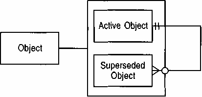

图 5.5 对象被另一个对象取代。

Figure 5.5 Object superseded by another.

委托给活动对象。如果所有数据都被复制，则活动对象可以安全地忽略已被取代的对象。

delegated to the active object. If all data is copied, then the active object can safely ignore the presence of superseded objects.

例如，采用替代策略时，JS777 对象会被标记为已替代，而 JS123 则成为活动对象。发送到 JS777 的任何消息都会被委托给 JS123。

Example With the superseding strategy the JS777 object is marked as superseded and the JS123 as the active object. Any messages sent to JS777 are delegated to JS123.

例如，研究人员发现了两种肝炎：输血后肝炎和非甲非乙型肝炎。后来，人们认为这两种肝炎是同一种，统称为丙型肝炎。这可以通过将输血后肝炎和非甲非乙型肝炎都归类到丙型肝炎对象来表示。

Example Researchers discovered two varieties of hepatitis: post-transfusion hepatitis and non-A non-B hepatitis. In time these were considered the same and called hepatitis C. This can be represented by superseding both the post-transfusion and non-A non-B hepatitis, linking them to the active hepatitis C object.

从概念上讲，复制替换策略和替代策略非常相似。唯一的区别在于，替代策略可以查看被替代对象最初附加的内容。这一点至关重要：如果医院在未意识到两位患者是同一人的情况下对史密斯先生进行了治疗，那么只有替代策略才能准确反映实际情况。

Conceptually the copy and replace strategy and the superseding strategies are much the same. The only difference is that you can look to see what was originally attached to the superseded object. This can be important: If a hospital performed treatment on Mr. Smith without realizing the two patients were the same, only the superseding strategy would give an accurate reflection of what happened.

##### 5.3.3 本质/外观

最后要考虑的策略是本质/表象模型，如图 5.6 所示。对象本身基本保持不变，但在其背后存在另一个对象——对象本质。对象本质的存在仅仅是为了连接不同的对象；它本身不具备其他属性。在这种策略中，合并是通过将对象连接到同一个对象本质来实现的。这意味着消息传递机制需要进行一些修改，因为对象必须了解自身的其他表象，并在做出响应时加以考虑。

The final strategy to consider is the essence/appearance model, shown in Figure 5.6. The object remains much the same, but sitting behind it is another object—the object essence. The object essence exists only to link together objects; it has no other properties. In this strategy merging is done by connecting the objects to a single object essence. This implies some message passing modification, in that objects must know about their other appearances and take them into account when responding.

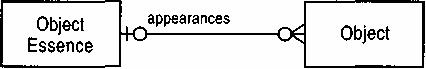

图 5.6 物体的本质和外观。

Figure 5.6 Object essence and appearance.

例如，使用本质/外观策略，创建一个新的对象本质，其外观为 JS123 和 JS777。

Example With the essence/appearance strategy, a new object essence is created with JS123 and JS777 as its appearances.

例如，该模型不适用于前面的肝炎例子，因为输血后肝炎和非甲非乙肝炎的概念不再使用，丙型肝炎成为普遍接受的肝炎。

Example This model does not apply well to the preceding hepatitis example because the concepts of post-transfusion and non-A non-B hepatitis fell out of use, and hepatitis C became the one that was generally accepted.

以上讨论主要集中在对象合并上；然而，合并操作之后可能需要撤销。例如，医院合并了两名患者后，几个月后可能会发现实际上存在两名不同的患者。如果采用本质/外观策略，则再次拆分对象最为简便，因为它能够保留原始对象。因此，如果合并操作的长期效果无法确定，本质/外观策略是最佳选择。

The discussion above has focused on merging objects; however, merging may need to be undone later. Having merged two patients, the hospital may find out a few months later that there really were two different patients after all. Splitting the objects again is easiest if the essence/appearance strategy was used, because it preserves the original objects. Thus the essence/appearance strategy is the best one to use should the merging not be certain in the long term.

例如，如果最终发现两个约翰·史密斯并非同一人，那么将他们联系在一起的对象本质就必须被移除。

Example Should the two John Smiths be found to be different after all, the object essence linking them together must be removed.

#### 5.4 对象等价性

#### 5.4 Object Equivalence

前几节主要讨论了不同的人如何以不同的方式识别同一个对象。一个相关但略有不同的观点是，不同的对象也可以被认为是相似的。例如，医学术语包含各种或多或少标准化的词汇来定义不同的临床状况。然而，重点在于“或多或少”。这些定义相当精确，当然与大多数软件术语相比，但并非完全精确。为了解决这种不精确性，人们制定了各种医学术语编码方案，这意味着我们需要从几种这样的编码方案中进行选择。

The previous sections have focused on how one object can be identified by different people in different ways. A related, though subtly different, point is that different objects can be considered similar. For example, medical terminology includes various more-or-less standard words to define various clini cal conditions. The emphasis, however, is on "more-or-less." The definitions are fairly precise, certainly in comparison to most software terms, but are not completely so. To handle this imprecision, various coding schemes for medical terms have been set up, which means we have several such coding schemes we must choose from.

我们可以将编码方案用作我们自身术语的识别方案。因此，如果某个临床医生使用一组特定的生物学现象，他可以通过将编码方案视为识别方案，将各种编码方案映射到这些生物学现象。其他临床医生也可以这样做。这使得信息得以传递，至少可以达到编码方案的粒度级别。这里容易被忽略的一个重要问题是，当等价性并非普遍认可时。一些参与方可能认为两个对象相同，而另一些参与方则不这么认为。图 5.7 中的模型通过定义某些参与方认可的等价性来解决这个问题。只有认可该等价性的参与方才能使用该等价性。

We could use a coding scheme as an identification scheme for our own terms. Thus if a particular clinician uses a particular set of biological phenomena, that clinician can map the various coding schemes to the biological phenomena by treating the coding scheme as an identification scheme. Other clinicians can do the same. This allows information to be transferred, at least to the level of granularity of the coding scheme. An important issue that can get lost here is when the equivalence is not universally agreed on. Some parties may think that two objects are the same while other parties do not. The model in Figure 5.7 deals with this by defining an equivalence that is held by certain parties. A party can make use of the equivalence only if it approves of it.

Example Many doctors consider the diseases hepatitis G and hepatitis GBC to be the same disease, but this is not universal. This can be represented by an equivalence be-

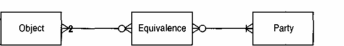

图 5.7 对象之间的等价关系。

Figure 5.7 Equivalences between objects.

tween these two diseases. If a doctor wants a list of patients suffering from hepatitis G and that doctor is a party on the equivalence, then those patients suffering from hepatitis GBC are also returned.

#### 参考

#### References

1. Martin, J. 和 J. Odell.面向对象方法：基础。Englewood Cliffs, NJ: Prentice-Hall, 1995。
2. Martin, J. and J. Odell. Object-Oriented Methods: A Foundation. Englewood Cliffs, NJ: Prentice-Hall, 1995.

[figure not shown]

### 第六章 库存和会计

### Chapter 6. Inventory and Accounting

很大一部分商业计算机系统旨在追踪企业内部的资金流动，记录资金的赚取和支出情况。会计和库存追踪的基本理念是，资金和货物被分成不同的“罐”，我们必须记录资金和货物如何在这些“罐”之间流动。

A large proportion of commercial computing systems are designed to track the money moving through an enterprise, recording how it is earned and spent. The fundamental idea behind accounting and inventory tracking is that there are various pots of money and goods, and we must record how money and goods move among these pots.

本章的库存和会计模式均源于这一基本理念。它们提出了一系列核心概念，可作为财务会计、库存管理或资源管理的基础。这些模式并非直接描述这些流程，而是阐述构建流程所依据的底层理念。第七章通过一个简单的示例，运用这些理念对电话计费进行了说明。

The inventory and accounting patterns in this chapter are born from this fundamental idea. They present a core set of concepts that we can use as the basis for financial accounting, inventory, or resource management. The patterns do not describe these processes directly, rather they describe the underlying ideas from which processes can be built. Chapter 7 describes a simple example that uses these ideas for billing telephone calls.

本章我将以一个简单的个人财务案例来解释会计和库存的基本概念。虽然概念相似，但我使用的术语并非传统财务会计术语。为了构建一个更抽象的模型，我发现需要引入一些新的术语和概念。本章模式的一个显著特点是将处理规则嵌入到账户系统中。这种方法使得账户能够自我更新和管理，从而将传统的被动记录系统转变为一个可以通过适当连接账户进行配置的主动系统。

In this chapter I use a simple personal financial example to explain the basic ideas of accounting and inventory. Although similar, the terms I use are not the terms traditionally used in financial accounting. In my search for a more abstract model, I found that I needed new terms and concepts. A particular feature of the patterns in this chapter is how the rules for processing are embedded into the accounts system. This approach allows the accounts to update and manage themselves. This turns a traditionally passive recording system into an active system that can be configured by wiring up the accounts in the appropriate manner.

第一种模式是账户（6.1）。账户存放有价值的物品——货物或金钱——这些物品只能通过记账进行增减。记账记录了账户的所有变动历史。当我们使用账户记录价值变动历史时，务必确保记录不会丢失。交易（6.2）通过将记账条目关联起来，进一步增强了可审计性。在交易中，从一个账户提取的物品必须存入另一个账户；物品不能被创建或销毁。

The first pattern is that of an account (6.1). An account holds things of value—goods or money—which can only be added or removed by entries. The entries provide a history of all changes to the account. When we use an account to record the history of changes to a value, it is important to check that items do not get lost. Transactions (6.2) add a further degree of auditabil-ity by linking entries together. In a transaction, the items withdrawn from one account must be deposited in another; items cannot be created or destroyed.

交易分为两种：两段式交易是指将金额从一个账户转移到另一个账户；多段式交易可以在多个账户中进行，只要整个交易的金额最终平衡即可。

There are two kinds of transactions: A two-legged transaction moves an amount from one account to another. A multilegged transaction can have entries in several accounts as long as the transaction as a whole balances.

可以使用汇总账户（6.3）将账户分组，汇总账户会将大多数账户的报告功能应用于账户组。有时我们需要进行一些并非旨在保持平衡的账户分录；备注账户（6.4）用于处理此类任务。

Accounts can be grouped together using a summary account (6.3), which applies most of account's reporting behavior to groups of accounts. Sometimes we need to make account entries that are not designed to be kept in balance; a memo account (6.4) deals with this task.

账户可以包含用于管理账户间金额转移的固定规则。过账规则（6.5）允许我们构建相互更新并反映业务规则的活跃账户网络。为了实现这一点，过账规则的实例需要拥有各自的可执行方法，这一要求引入了重要的建模概念——个体实例方法（6.6）。个体实例方法可以通过单一子类型、策略模式、内部 case 语句、解释器和参数化方法的某种组合来实现。

An account can include fixed rules that govern how amounts are transferred between accounts. Posting rules (6.5) allow us to build active networks of accounts that update each other and reflect business rules. To achieve this, instances of a posting rule require their own executable methods, a requirement that introduces the important modeling concept of an individual instance method (6.6). Individual instance methods can be implemented with some combination of a single subtype, the strategy pattern, an internal case statement, an interpreter, and a parameterized method.

过账规则执行（6.7）模式描述了触发过账规则的方式：在创建交易时；通过请求账户处理其规则；通过请求触发过账规则；或者通过请求账户更新自身，从而以向后链接的方式触发其前身。

The posting rule execution (6.7) pattern describes ways in which posting rules can be triggered: while a transaction is created; by asking an account to process its rules; by asking a posting rule to fire; or by asking an account to bring itself up to date, thus firing its predecessors in a backward chaining manner.

要将过账规则应用于多个账户，我们需要一种方法来定义多个账户的过账规则（6.8）。一种方法是使用知识层级，在这种情况下，过账规则是基于账户类型定义的。另一种方法是将过账规则链接到汇总账户。

To use posting rules with many accounts, we need a way of defining posting rules for many accounts (6.8). One way is to use a knowledge level, in which case posting rules are defined on account types. Another way is to link posting rules to summary accounts.

在会计系统中，各种对象需要账户条目及其余额的子集，这两者都需要一种选择条目的模式（6.9）。当我们想从多值映射中选择对象时，这种模式非常有用。其他方法包括返回整个集合并让客户端进行选择、向账户添加额外操作或使用账户过滤器。

In an accounting system, various objects will want subsets of the account's entries and their balances, both of which require a pattern for choosing entries (6.9). This pattern is useful whenever we want a selection of objects from a multivalued mapping. Our alternatives are to return the whole set and let the client do the selection, adding extra operations to the account, or using an account filter.

我们可以利用会计实务（6.10）模式将庞大的记账规则网络划分成若干组。在进行长时间的计算时，我们经常需要回溯分析，了解各个交易产生特定结果的原因；这时，我们就需要使用条目来源（6.11）模式。

We can divide large networks of posting rules into groups by using the accounting practice (6.10) pattern. In long calculations we often need to go back to see why various transactions gave the result they did; then we need to use the sources of an entry (6.11) pattern.

资产负债表和损益表（6.12）区分了记录持有项目的账户和记录资金流入或流出的账户。不同的人对账户的看法可能相似；例如，我对我的银行账户的看法可能与我的银行的看法相似。两者互为对应账户（6.13）。

Balance sheets and income statements (6.12) distinguish between accounts that record items being held and accounts that record where items come or go. Different people can have similar views of accounts; for example, my view of my bank account is probably similar to my bank's view. One is a corresponding account (6.13) of the other.

由此产生的模式相当抽象；具体案例需要专门的会计模型（6.14）才能将其应用于日常实践。这类会计模型是通过对一般会计模式进行细分而构建的。

The resulting patterns are quite abstract; particular cases need a specialized account model (6.14) to apply them to everyday practice. Such accounts are developed by subtyping the general accounting patterns.

本章最后一个模式描述了记账分录到多个账户的情况（6.15）。当有多种方式可以记录分录路径时，此模式非常有用。两种替代方法是使用备注分录或使用派生账户。当我们想要账户的报表功能，但不需要账户的平衡和审计功能时，可以使用派生账户代替会计模式。

The final pattern in this chapter describes booking entries to multiple accounts (6.15). This pattern is useful when there is more than one way of reporting the trail of entries. The two alternative techniques are using memo entries or using derived accounts. We can use derived accounts instead of accounting patterns when we want the reporting behavior of accounts but not the balancing and audit capabilities.

这些模型是多个项目过程中产生的理念的结晶。它们最初源于为一家美国公用事业公司开发客户服务系统，并在研究一家国际电信公司的会计结构时得到进一步完善。此外，这些模型也大量借鉴了近期为一家美国大型制造公司开发的薪资系统。

These models are the results of ideas generated during several projects. They originated from working on a customer service system for a US utility company, and were further developed while examining accounting structures for an international telecommunications company. The models also draw deeply from the recent development of a payroll system for a major US manufacturing company.

关键概念：账户、交易、分录、过账规则

Key Concepts Account, Transaction, Entry, Posting Rule

#### 6.1 账户

#### 6.1 Account

在许多领域，不仅需要记录某物的当前价值，还需要记录影响该价值的每一次变动的细节。例如，银行账户需要记录每一次取款和存款；库存记录需要记录每一次物品的增减。

In many fields it is important to keep a record of not only the current value of something but also details of each change that effects that value. A bank account needs to record every withdrawal and deposit; an inventory record needs to record each time items are added or removed.

账户类似于数量属性，其值每次变化都会添加一条记录，如图 6.1 所示。余额代表账户的当前值，是与该账户关联的所有记录的净值。但这并不意味着每次查询余额时都需要重新计算。派生值可以缓存，但缓存对账户用户是不可见的。通过使用这些记录，客户还可以确定一段时间内的变化以及存款或取款的总额（参见 6.9 节）。金额旁边的符号表示该记录是存款还是取款。对账单是一段时间内针对某个账户执行的所有记录的列表。

An account is similar to a quantity attribute, with an added entry for every change to its value, as shown in Figure 6.1. The balance, which represents the current value of the account, is the net effect of all entries linked to the account. This does not mean that the balance needs to be recalculated each time it is asked for. Derived values can be cached, although the cache would be invisible to the account user. By using the entries, a client can also determine the changes over a period of time and the total amount of deposits or withdrawals (see Section 6.9). The sign on the amount indicates whether the entry is a deposit or a withdrawal. A statement is a list of all the entries that have been carried out against an account over a period of time.

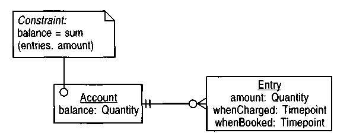

图 6.1 账户和条目。

Figure 6.1 Account and entry.

这些条目记录了账户的每一项变更。

The entries record each change to the account.

例如，我从支票账户中提取了 100 美元。这会在我的支票账户中显示为一笔金额为 -100 美元的记录。

Example I withdraw $100 from my checking account. This is represented as an entry with amount -$100 attached to my checking account.

例如，我从商店购买了4令标准信纸。商店在其标准信纸账户中将此笔交易记为金额-4令。

Example I buy 4 reams of standard letter paper from a shop. The shop represents this as an entry on their standard letter paper account with amount -4 reams.

例如，1月份我使用了350千瓦时的电量。这会在我的家庭用电量账户中记录为一笔350千瓦时的用电量。

Example In January I use 350 KWH of electricity. This is represented as an entry with amount 350 KWH to my domestic electricity usage account.

**建模原理**

**Modeling Principle**

*要记录某个值的变化历史，请使用该值的帐户。*

*To record a history of changes to a value use an account for that value.*

计算余额的一种方法是获取一组条目，并将其转换为一组数量。Smalltalk 提供了一个专门的 `collect` 操作来实现这一点。但问题在于，`collect` 操作会将对象收集到与原始集合类型相同的集合中。因此，对一组条目运行 `collect` 操作会得到一组数量。集合不允许重复元素，所以如果两个条目的数量相同，则只会计算第一个条目的数量，导致余额计算错误。为了创建基本值的集合，通常最好使用允许重复元素的 `bag` 对象。在 C++ 中，这个问题不太常见，因为 `collect` 操作不太常用且更难使用；C++ 用户通常使用外部迭代器 [ I ]，它不存在这个问题。但是，为了确保万无一失，测试用例应该始终包含数量相等的条目（以及所有属性都相等的条目）。

One way an implementation can compute a balance is to take a collection of entries and form a collection of quantities. Smalltalk has a specific operation, collect, to do this. The danger is that the collect operation collects the objects into the same kind of collection as the original. Thus running collect on a set of entries yields a set of quantities. Sets allow no duplicates, so if we have two entries with the same amount, only the first entry's quantity is counted, and the balance value is incorrect. To form collections of fundamental values, it is often better to use a bag, which does allow duplicates. In C++ this problem is less common because collect operations are less common and more difficult to use; instead C++ users use an external iterator [ I ] which does not have this problem. As a check, however, test cases should always include entries with equal amounts (as well as entries with every attribute equal).

图 6.1 显示了该笔交易的两个时间点：一个表示费用产生的时间，另一个表示该笔交易记入账户的时间。这在发生追溯费用时尤为重要。费用价格可能在费用产生日期和记账日期之间发生变化，因此这两个日期都必不可少。我们需要了解事件的历史记录以及我们对该历史记录的了解（参见 15.3.1 节）。时间点还包括具体的时间和日期；许多应用程序仅需日期即可。

Figure 6.1 indicates two timepoints for the entry: one indicates when the charge is made and the other when the entry is booked to the account. This is particularly important when retroactive charges occur. A price for a charge may have changed between the charge date and the booked date, so both dates are required. We need to know both the history of events and our knowledge of that history (see Section 15.3.1). Timepoints also include both the time of day as well as the date; many applications are happy with just the date.

例如，我于 4 月 1 日在 Jae's Cafe 用餐。信用卡公司于 4 月 4 日收到付款通知。该笔消费的扣款日期为 4 月 1 日，预订日期为 4 月 4 日。

Example I have a meal at Jae's Cafe on April 1. The credit card company receives notice of payment on April 4. The entry has a charged date of April 1 and a booked date of April 4.

#### 6.2 交易

#### 6.2 Transactions

使用记账方式有助于记录账户的变动。这些变动通常涉及将资金从一个账户转移到另一个账户。例如，当我从银行账户取款时，我实际上是在往我的钱包（或现金账户）里充值。对于很多资金的流入和流出，仅仅记录是不够的；我们还必须记录它们的来源和去向。

Using entries help keep a record of changes to an account. These changes usually involve moving an item from one account to another. When I withdraw money from my bank account, I am adding money to my wallet, or cash account. With many items it is not enough to just record the comings and goings; we must also record where they come from and go to.

如图 6.2 所示，该交易通过将一个账户的取款与另一个账户的存款明确关联起来而有所帮助。复式记账法反映了一个非常基本的会计原则，即货币（或我们必须记录的任何其他东西）既不会被创造也不会被消灭，它只是从一个账户转移到另一个账户。

The transaction helps by explicitly linking a withdrawal from one account to a deposit in another, as shown in Figure 6.2. The double entry approach reflects a very basic accounting principle that money (or anything else we must account for) is never created or destroyed, it merely moves from one account to another.

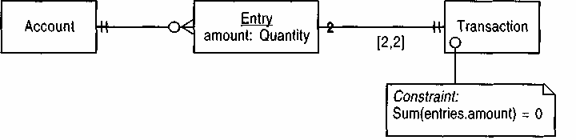

图 6.2 包含两条记录的交易。

Figure 6.2 A transaction with two entries.

例如，我用信用卡向波士顿航空公司支付了 500 美元购买机票。这是一笔从信用卡账户到波士顿航空公司账户的 500 美元转账。之后，我会从我的支票账户向信用卡账户转账，使信用卡账户余额归零。

Example I use my credit card to pay Boston Airlines $500 for an airline ticket. This is a transaction from the credit card account to the Boston Airlines account with an amount of $500. Later I will make a transaction from my checking account to the credit card account to bring the credit card account's balance to zero.

例如， Aroma Coffee Makers (ACM) 将 5 吨阿拉伯摩卡咖啡从纽约运往波士顿。这是一笔从纽约账户到波士顿账户的交易，金额为 5 吨。

Example Aroma Coffee Makers (ACM) moves 5 tons of Arabian Mocha from New York to Boston. This is transaction from the New York account to the Boston account with an amount of 5 tons.

在复杂的会计结构中，我们的目标是在业务周期的各个阶段实现账户平衡，即余额为零。通过将守恒原则融入模型，我们可以更轻松地发现系统中的任何“漏洞”。虽然使用账户时并非必须使用交易记录，但我个人更倾向于使用交易记录。

In complex accounting structures we aim to get the accounts to balance— that is, to reach zero—at various points in the business cycle. By building the principle of conservation into the model, we make it easier to find any "leaks" in the system. Although it's not essential to use transactions when you are using accounts, I prefer to.

**建模原理**

**Modeling Principle**

*在处理账务时，应遵循守恒原则：被记录的资产既不能被创造，也不能被销毁，只能从一个地方转移到另一个地方。这样更容易发现和避免数据泄露。*

*When working with accounts, follow the principle of conservation: The item being accounted for cannot be created or destroyed, only moved from place to place. This makes it easier to find and avoid leaks.*

##### 6.2.1 多腿交易

图 6.2 表明每笔交易都包含一次取款和一次相应的存款。实际上，一笔交易中可以包含多次取款和存款。假设我从 Megabank 收到 3000 美元，从 Total Telecommunications 收到 2000 美元。我决定将这两张支票存入我的支票账户。我的银行对账单将显示 5000 美元的贷方余额。请注意，尽管我的银行账户收到了两张支票，但只显示一条记录。这笔交易可以用图 6.3 所示的多腿交易模型来表示。映射的上限从交易提升到记录。最基本的规则是，记录必须相对于整个交易保持平衡，但单个记录之间不需要完全匹配。因此，我可以用包含三个记录的交易来模拟我的银行账户情况：[账户：

Figure 6.2 implies that each transaction consists of a single withdrawal and a single corresponding deposit. In fact we can have many withdrawals and deposits in a transaction. Say I receive $3000 from Megabank and $2000 from Total Telecommunications. I decide to deposit both checks into my checking account. My bank statement will show a $5000 credit. Note that although two checks have hit my bank account, a single entry is shown. This transaction is represented by the multilegged transaction model shown in Figure 6.3. The upper bound on the mapping is lifted from transaction to entry. The overriding rule is that the entries must balance with respect to the whole transaction, but no match is required among individual entries. Thus I can model my bank account situation with a transaction that consists of three entries: [account:

支票账户，金额：5000 美元]，[账户：Megabank，金额：(3000 美元)]，[账户：Total Telecommunications，金额：(2000 美元)]。该交易负责确保资金不会被创造或销毁。

checking account, amount: $5000], [account: Megabank, amount: ($3000)], [account: Total Telecommunications, amount: ($2000)]. The transaction is responsible for ensuring that money is not created or destroyed.

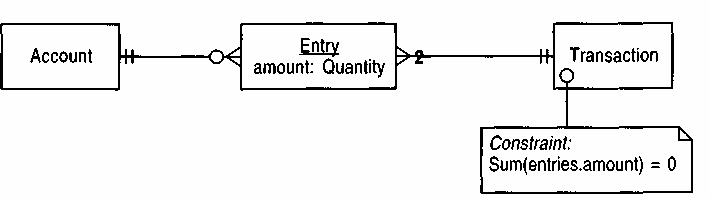

图 6.3 多腿交易。

Figure 6.3 Multilegged transactions.

与传统的双腿模式相比，这些模式在交易形成方面提供了更大的灵活性。

These allow more flexibility in forming transactions than the two-legged model.

例如， Aroma Coffee Makers 从纽约运出 5 吨 Java，并将 2 吨运往波士顿，3 吨运往华盛顿。这是一笔包含三个条目的交易：[账户：纽约，-5 吨]，[账户：波士顿，2 吨]，[账户：华盛顿，3 吨]。

Example Aroma Coffee Makers removes 5 tons of Java from New York and sends 2 tons to Boston and 3 tons to Washington. This is a single transaction with three entries: [account: New York, -5 tons], [account: Boston, 2 tons], [account: Washington, 3 tons].

双腿交易模型是多腿交易模型的一种特殊情况，其中交易只有两个条目。在某些应用中，双腿交易模型占主导地位，其模型类似于图 6.4。其他应用可能包含大量的多腿交易。我推荐使用多腿交易方法，因为它提供了更大的灵活性。可以通过对多腿交易执行特殊的创建操作轻松创建双腿交易，这非常方便。本文的其余部分均基于多腿交易模型进行讨论。

The two-legged model is a particular case of the multilegged model where the transaction has only two entries. In some applications the two-legged model predominates, and we have a model similar to Figure 6.4. Other applications might have a large number of multilegged transactions. I would recommend the multilegged approach because it provides more flexibility. Two -legged transactions can easily be created by a special creation operation on a multilegged transaction, which is a useful convenience. The rest of this discussion assumes the multilegged model.

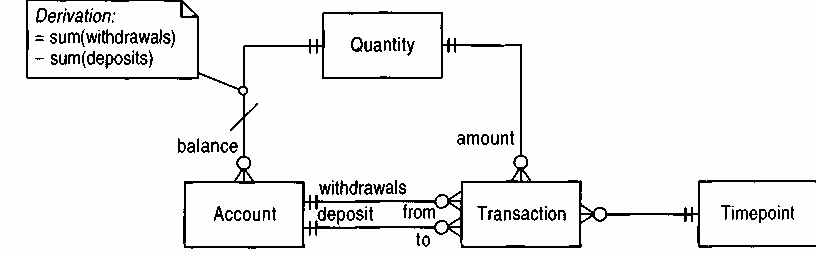

图 6.4 不使用条目的双腿交易模型。

Figure 6.4 A model of a two-legged transaction that does not use entries.

这种模型适用于所有交易均为两腿交易的情况。它的 功能与图 6.2 基本相同。但是，我更倾向于使用图 6.2，因为它更容易 迁移到多腿交易。

This model may be found where all the transactions are two-legged. It has much the same capabilities as Figure 6.2. However, I would prefer using Figure 6.2 since it is easier to migrate to a multilegged transaction.

交易和条目之间相互强制的关系引入了一个先有鸡还是先有蛋的问题。由于某种约束，我不能在不创建交易的情况下创建条目。同样，我也不能在不创建条目的情况下创建交易，因为交易也受到类似的约束。

The mutual mandatory relationship between transaction and entry introduces a chicken and egg problem. I cannot create an entry without creating a transaction because of a constraint. Similarly I can't create a transaction without an entry because transaction is similarly constrained.

一种解决方案是在事务上提供一个创建操作，该操作接受一个部分定义的条目列表，甚至是带有适当参数的数组列表。条目的创建操作将被设为私有，但事务的创建操作可以访问它。这样，事务的创建操作就成为唯一可以创建条目的地方。显然，在执行此创建操作期间，对象将违反其约束。然而，约束规则是，公共操作应在所有约束都得到满足后结束[5]。只要将事务的创建例程设为公共，就可以强制执行此规则。

One solution is to provide a creation operation on transaction that takes a list of partially defined entries, or even a list of arrays with appropriate arguments. Entry would have its creation operation made private but accessible to the transaction's creation. The transaction's creation would then be the only place that could create entries. Obviously, during the execution of this creation operation, objects would be in violation of their constraints. The rule with constraints, however, is that public operations should end with all constraints satisfied [5]. Providing only the transaction's creation routine is made public, this rule can be enforced.

#### 6.3 汇总账户

#### 6.3 Summary Account

在会计系统中，将账户分组通常很有用。例如，我可能希望将我的 Total Telecommunications 账户和 Megabank 账户合并到一个营业收入账户中。同样，我希望将房租和伙食费计入个人支出，将商务旅行和办公费用计入营业支出。这种结构可以通过简单的明细账户和汇总账户层级结构来支持，如图 6.5 所示。

In a system of accounts it is often useful to group accounts together. For example, I might want to group my Total Telecommunications and Megabank accounts into a business income account. Similarly I want to put rent and food into personal expenses and my business travel and office expenses into business expenses. This kind of structure can be supported with a simple hierarchy of detail and summary accounts, as shown in Figure 6.5. components

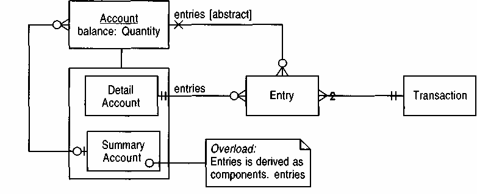

[等级制度]

[hierarchy]

图 6.5 汇总和明细账户。

Figure 6.5 Summary and detail accounts.

汇总账户可以由汇总账户和明细账户组成。这形成了 一个层级结构，明细账户位于叶节点（复合账户的一个例子[1]）。 汇总账户的条目以递归方式从其组成部分的条目派生而来 。

A summary account can be composed of both summary and detail accounts. This forms a hierarchy, with the detail accounts as leaves (an example of composite [1]). The entries of a summary account are derived from the components' entries in a recursive manner.

在这个层级结构中，我们可以将账户合并成汇总账户。我们将系统限制为仅向明细账户过账，而不向汇总账户过账。汇总账户仍然可以被视为账户，因为它们的条目是根据其组成部分的条目派生而来的。包含汇总账户的汇总账户会递归地在其组成部分、其组成部分的组成部分以及依此类推地查找条目。这种条目映射的派生方式使我们能够在超类型级别描述余额属性以及任何其他依赖于条目的操作和属性。

In this hierarchy structure we can bring together accounts into summary accounts. We restrict the system to posting entries only to detail accounts and not to summary accounts. Summary accounts can still be treated as accounts because their entries are derived according to their components' entries. A summary account that contains summary accounts will look for entries in its components, its components' components, and so on, recursively. This derivation of the entries mapping allows us to describe the balance attribute, and any other operations and attributes that depend on entries, at the supertype level.

例如，我有一个航空旅行汇总账户，其中包含 Mega-bank 航空旅行和 Total Telecommunications 航空旅行的详细账户。

Example I have a summary account for air travel with detail accounts for Mega-bank air travel and Total Telecommunications air travel.

例如， Aroma Coffee Makers公司有一个Java的汇总账户，每个仓库则有详细的账户。因此，它可以算出自己拥有的Java总量。

Example Aroma Coffee Makers has a summary account for Java with detail accounts for each warehouse. It can thus find out the total amount of Java that it owns.

请注意，组件之间的关系需要加以标记，以表明其层级结构。仅凭基数不足以强制执行此约束。此结构中绝不能存在循环。

Note that the relationship among components needs to be marked to show it is a hierarchy. The cardinalities are not enough to enforce this constraint. We must not have cycles in this structure.

在会计中，汇总账户和明细账户的分离非常普遍，但并非绝对必要。图 6.6 中的模型取消了这种区分。在这种情况下，任何账户都可以进行记账，并且所有账户都可以置于层级结构中。这可以通过提供两个从账户到记账项的映射来实现：一个映射用于显示该层级已过账的记账项，另一个映射用于汇总子账户中的记账项。第一个映射是可更新的，第二个映射是派生的，不可更新，用于余额、报表以及图 6.5 模型中超类型上的其他功能。

The separation between summary and detail accounts is quite common in accounting, but it is not absolutely necessary. The model in Figure 6.6 shows the distinction removed. In this case an entry can be made to any account, and all accounts can be placed in a hierarchical structure. This can be done by providing two mappings from account to entry: one to show which entries are posted at that level, and another to add together the entries on sub-accounts. The first would be updatable, the latter is derived, not updatable, and used for balance, statements, and other features that were on the super-type in the Figure 6.5 model.

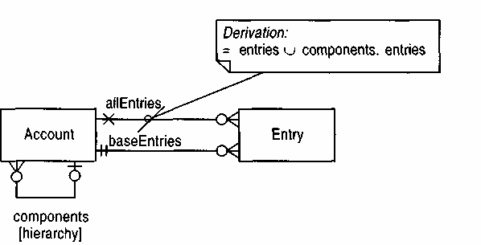

图 6.6 未区分汇总账户和明细账户的账户层级结构。

Figure 6.6 Account hierarchies without separating summary and detail accounts. We

可以使用此模型将条目发布到汇总帐户。

can use this model to post entries to summary accounts.

到目前为止，我们一直遵循的惯例是账户必须按层级排列，并且每笔交易只能记入一个账户。我们将继续沿用这些假设一段时间，但稍后将在6.15节中探讨一些其他可能性。

So far we have followed conventions that say that accounts must be arranged in a hierarchy and that entries are booked to only one account. We will continue with these assumptions for a while, but we will consider some alternative possibilities later on in Section 6.15.

#### 6.4 备忘录账户

#### 6.4 Memo Account

本杰明·富兰克林曾说过：“在这个世界上，唯有死亡和税收是确定无疑的。” 我们无法消除缴税的痛苦，但我发现，避免在报税时遇到意外情况，可以减轻一些痛苦。每次挣到钱，我都会将一部分存入一个税务账户。这样，我就能清楚地知道我的钱有多少是真正属于我的，又有多少是需要缴纳的税款。

Benjamin Franklin once said, "In this world nothing can be said to be certain, except death and taxes." We can't eliminate the pain of paying taxes, but I find the pain is lessened somewhat by avoiding surprises on my tax return. Each time I earn some money, I allocate a portion to a tax liability account. I then know how much of my money is really mine, and how much I owe in taxes.

请注意，根据此计划，实际上并没有资金流动。在我需要缴纳税款之前，我的支票账户不会有任何款项支付。此外，我的税款类别将州税和联邦税合并在一起。当我实际缴纳税款（以及预估税款）时，我会从我的支票账户向联邦税账户和州税账户进行转账。这样做时，我需要将我的纳税义务账户减少相应的金额，但实际上，实际的资金不会在支票账户、联邦税账户、州税账户和这个纳税义务账户之间流动。这个账户就像一份备忘录，提醒我欠了多少钱，因此被称为备忘录账户。

Notice that with this plan, no real money has moved. There is no payment from my checking account until I have to pay the tax. Furthermore, my tax category lumps together state and federal taxes. When I actually pay (and when I pay estimates], I will make transactions from my checking account to the accounts federal tax and state tax. When I do this I need to reduce my tax liability account by the same amounts, but again no money moves between the real accounts (checking account, federal tax, state tax) and this tax liability account. This account acts as a memo to me on how much money I owe in taxes, thus it is referred to as a memo account.

备忘录账户包含金额，但并非实际的资金。重要的是，不能让实际资金流入或流出备忘录账户。因此，在我的税务示例中，当我将资金从收入账户转入支票账户时，我同时也会在我的纳税义务备忘录账户中记入一笔款项。备忘录账户成为账户的另一种子类型，我必须确保交易不会在该账户与其他账户之间转移资金。这可以通过确保交易的余额限制排除备忘录账户来实现。

A memo account contains amounts of money but not real money. It is important that no real money leaks from or to a memo account. So in my tax example, as I take the money from my income account to my checking account I make an entry at the same time into my tax liability memo account. Memo account becomes another subtype of account, and I have to ensure that transactions do not shift money between that and the other accounts. This can be done by ensuring that the balance constraint on transaction excludes memo accounts.

如果我们使用交易，就需要确保资金始终在账户之间流动，并且不会创造或销毁资金。这意味着，当向纳税义务账户添加一笔分录时，需要在某个地方添加一笔平衡分录。由于很难确定哪个账户才是这笔分录的合理存放账户，会计人员通常会创建一个抵销账户。这样，纳税义务账户就拥有一个抵销纳税义务账户，作为纳税义务账户中所有分录（无论是取款还是存款）的另一端。这种方法可以与常规模型一起使用，但并非绝对必要。如果余额检查约束忽略备忘录账户，则允许对备忘录账户进行单边分录。抵销账户始终可以自动生成。这种方法意味着从交易到分录的映射的下限可以降低到 1。

If we are using transactions, we need to ensure that we always move money between accounts and that we do not create or destroy money. This implies that when an entry is made to the tax liability account, a balancing entry is made somewhere. Since it can be difficult to see what account would be a sensible host to this entry, accountants frequently create a contra account. Thus the tax liability account would have a contra tax liability account, which acts as the other end of all entries in the tax liability account, either withdrawals or deposits. This approach can be used with the usual model, but it is not strictly necessary. If the balance checking constraint ignores memo accounts, then single-sided entries against them are allowed. A contra account can always be generated automatically. This approach would imply that the lower bound on the mapping from transaction to entry can be reduced to 1.

例如，每次收到客户付款时，我都会将其记录为一笔从客户收入账户到我支票账户的交易。同时，我还会将部分款项记入税务负债备忘账户。到了缴纳预估税款的时候，我会从我的支票账户向我的联邦税账户进行一笔交易。此外，我还会为这笔交易添加第三笔记录，将税务负债备忘账户中的金额减少相同的数额。

Example Each time I receive a payment from a client, I record it as a transaction from a client income account to my checking account. I also enter a portion of that amount into the tax liability memo account. When the time comes to pay estimated taxes, I make a transaction from my checking account to my federal tax account. I add a third entry to this transaction to reduce the amount on my tax liability memo account by the same amount.

当然，如果我们不使用交易，就不会遇到任何余额问题，可以放心地过账，但危险在于真金白银更容易流入备忘录账户（或凭空消失）。

Of course, if we don't use transactions, we don't run into any balance problems and can post the entries without worry, but the danger is that real money can leak into memo accounts (or into thin air) more easily.

#### 6.5 发帖规则

#### 6.5 Posting Rules

我可以使用备忘账户将款项记入税务负债账户，但我仍然需要记住去操作。由于我总是将每笔费用收入的 45% 记入税务负债备忘账户，因此计算机系统应该能够自动完成这项工作。

Using a memo account I can make a posting to a tax liability account, but I still have to remember to do it. Since I always enter 45 percent of each fee income entry into a memo tax liability account, a computer system should be able to do it for me automatically.

我们需要一条规则，该规则会检查特定账户，并在发现该账户中有条目时创建另一条条目。图 6.7 展示了此类规则的一个简单示例。过账规则通过指定一个账户作为触发器来描述。触发账户中的任何条目都会触发创建新条目，新条目的值是原始条目值乘以一个乘数。

What is needed is a rule that looks at a particular account and, when it sees an entry, creates another entry. A simple example of this kind of rule is shown in Figure 6.7. A posting rule is described by specifying an account as a trigger. Any entry in the trigger account causes a new entry to be made, which is the value of the original entry multiplied by the multiplier.

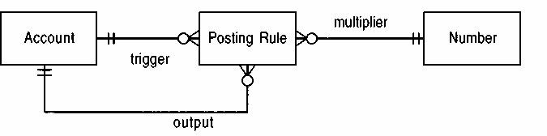

图 6.7 乘以一个因子的简单发布规则结构。

Figure 6.7 A simple structure for posting rules that multiply by a factor.

对于触发账户中的每个条目，我们将触发条目的值乘以乘数后，记入输出账户。

For each entry in the trigger account, we post an entry to the output account of the value of the triggering entry multiplied by the multiplier.

例如，我的纳税义务可以通过过账规则来处理，其中费用收入账户作为触发器，纳税义务账户作为输出，乘数为 0.45。

Example My tax liability can be handled by a posting rule with the fee income account as the trigger, the tax liability account as the output and the multiplier as 0.45.

标量乘法可以处理过账规则中的许多有用情况，但这个过程很容易变得复杂。例如，考虑累进所得税：前 300 英镑免税，接下来的 2500 英镑征收 20% 的税，其余部分征收 40% 的税。简单的标量乘数就不够用了。我们希望过账规则能够使用任意算法，从而获得最大的灵活性。

Multiplication by a scalar handles a number of useful situations for a posting rule, but the process can easily get complex. Consider a graduated income tax: The first £300 carries no tax, the next £2500 carries a 20 percent tax, the rest is at 40 percent. A simple scalar multiplier is no longer enough. We want posting rules to carry any arbitrary algorithm, which would give us the maximum flexibility.

为了赋予记账规则这种灵活性，我们必须将计算与记账规则的每个实例关联起来，因为每个规则计算新条目金额的方式都不同。从概念上讲，这意味着记账规则的每个实例都需要有自己的计算方法，如图 6.8 所示。glib 表示法掩盖了一个重要问题。主流对象系统允许通过多态和继承来改变行为，但这基于类：行为随对象的类而变化。我们希望行为随每个实例而变化，这就需要使用实例方法模式，如 6.6 节所述。（我在 9.2 节中讨论了一个类似的问题。）

To give posting rules this flexibility, we have to link a calculation to each instance of a posting rule, since every rule will have a different way of calculating the amount of the new entry. Conceptually this means that each instance of a posting rule needs to have its own method for doing the calculation, as shown in Figure 6.8. The glib notation masks a significant problem. Mainstream object systems allow behavior to vary by polymorphism and inheritance, but this is class based: The behavior varies with the object's class. We want the behavior to vary with each individual instance, which requires the individual instance methods pattern, as discussed in Section 6.6. (I discuss a similar problem in Section 9.2.)

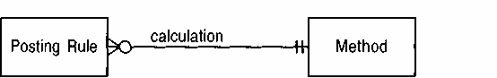

图 6.8 带有计算条目值的方法的过账规则。

Figure 6.8 Posting rules with methods to calculate values for entries.

这种表示法表明，每个发布规则实例都有自己的计算方法。

This notation says that each instance of a posting rule has its own calculation method.

##### 6.5.1 可逆性

过账规则的一个重要特性是它们必须是可逆的。通常我们无法删除错误的条目，因为它要么导致了付款条目，要么出现在账单上。我们只能通过输入冲销条目来消除其影响，即输入一个相同但方向相反的条目。因此，任何过账规则都必须确保两个相同但符号相反的条目都被放入触发账户，并在后续处理中完全相互抵消。我们可以通过在过账规则的例程中插入这样的相反条目对来测试冲销功能，并确保它们的输出金额也相等且方向相反。

An important property of posting rules is that they must be reversible. Usually we cannot delete an incorrect entry because either it has led to an entry that is part of a payment or it appears on a bill. The only way we can remove its effects is by entering a reversal, which is an identical but opposite entry. Thus any posting rule must ensure that two entries that are identical but of opposite signs are both placed in the trigger account and completely cancel each other out in further processing. We can test the reversal by inserting such opposite pairs in routines for a posting rule and ensuring their output amounts are also equal and opposite.

##### 6.5.2 放弃交易

在某些账户中，几乎所有交易都由过账规则生成。输入账户用于记录来自外部的初始条目。所有后续的账户条目均由过账规则生成。由于所有条目都可以根据初始条目和过账规则进行预测，因此不使用交易的风险降低。检查是否存在数据泄露的责任从系统运行转移到了过账规则的设计阶段。即使我们移除交易，记录条目之间的因果关系仍然很有价值。总的来说，我更倾向于保留交易，因为它们只需付出少量额外成本即可简化审计工作。即使不使用交易，您仍然需要某种审计机制。

In some accounts almost all transactions are generated from posting rules. Input accounts are used to record initial entries from the outside world. All further account entries are generated by posting rules. The risk of not using transactions is reduced because all entries are predictable from the initial entries and the posting rules. The responsibility to check that nothing leaks out is transferred from the operational use of the system to the design of the posting rules. If we remove transactions, then it is still valuable to keep a note of the cause and effect trail between entries. On the whole I prefer keeping transactions because they make auditing easier for a small price in overhead. If you don't use transactions, you will still need some audit mechanism.

#### 6.6 个别实例法

#### 6.6 Individual Instance Method

为了方便领域专家理解，概念模型应尽可能自然地呈现实际情况。我们应尽可能减少对特定实现环境的依赖。计算机设计应反映人类思维，而非反之。图 6.8 所示的图表体现了这一理念。定义好概念模型结构后，我们需要找到一种通用的实现方法。因此，问题不再是“如何对单个发布规则进行计算？”，而是“如何将方法附加到实例？”。这遵循了第 14 章讨论的转换方法。我们希望在单一接口背后，有多种实现图 6.9 中模型的方法。这遵循基于模板设计的首要原则：模型应定义类的接口。我们应该能够在不改变接口的情况下替换实现。

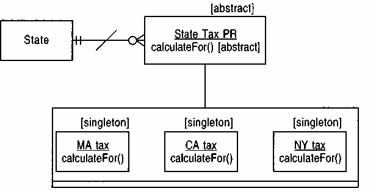

图 6.9 使用单例类实现各个实例方法。

Figure 6.9 Using singleton classes to implement individual instance methods.

##### 6.6.1 使用单例类实现

改变行为的自然方法是使用基于子类化的多态操作。最简单的方法是为每个过账规则实例创建一个子类，从而创建多个单例类。所有标准方法和属性都由过账规则本身持有，子类仅实现不同的 `calculateFor` 方法。

The natural way to vary behavior is to use a polymorphic operation based on subclassing. The simplest way to do this is to subclass the posting rule for each instance of the posting rule, thus creating a number of singleton classes. Here all the standard methods and properties for posting rules are held by the posting rule, and the subtypes merely implement the different calculateFor methods.

这种方法的主要问题在于子类型相当人为。它们的存在仅仅是因为我们无法通过实例改变 `calculateValue` 的值。这种人为性使得该方法不够完美。另一个问题是，这种方法会导致类过多，这会让一些人感到不适。类本身并不是一个特别大的问题，因为这些类都很小且约束很多。计算方法可以通过操作类层次结构来共享。然而，过账规则的处理操作也可能受到多态性的影响，而这两种多态性可能并不匹配。

The main problem with this approach is that the subtypes are rather artificial. They only exist because of the fact we cannot vary calculateValue by instance. This artificiality makes the approach less than perfect. Another problem is that this approach leads to many classes, which makes some people feel rather uncomfortable. Classes do not present a particularly large problem because the classes are both small and very constrained. Calculation methods can be shared by manipulating the class hierarchy. However, the process operation on the posting rule can also be the victim of polymorphism, and the two polymorphisms may not match.

##### 6.6.2 采用策略模式的实施

乍一看，图 6.10 所示的策略模式 [1] 实现与使用单例的模式非常相似。主要区别在于，图 6.10 对一个单独的方法对象（或策略对象）执行子类型化。由于消除了方法选择的问题，发布规则也更简单。发布规则只需知道它可以请求一个方法对象来执行计算即可。

On first sight the strategy pattern [1] implementation shown in Figure 6.10 looks very similar to the pattern using singletons. The main difference is that Figure 6.10 performs subtyping on a separate method, or strategy, object. The posting rule is simpler because the whole issue of method choice is eliminated. The posting rule just knows it can ask a method object to do the calculation.

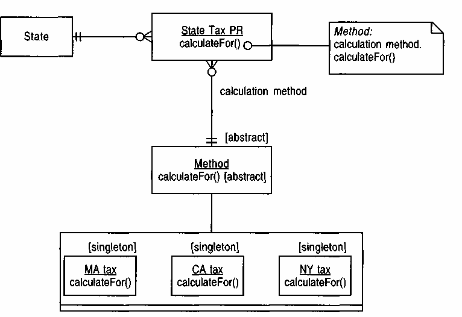

图 6.10 使用策略模式 [1] 实现各个实例方法。

Figure 6.10 Using the strategy pattern [1] implementation for individual instance methods.

图 6.11 展示了一个示例案例中的交互过程。一个账户请求处理规则对其进行处理。处理规则获取所有尚未被其处理的条目（参见 6.7.2 节）。对于每个条目，它调用自身的方法来计算新条目的值。该方法可能需要询问一些问题；例如，税率通常会根据个人是否已婚而有所不同。它将计算结果返回给记账规则，记账规则随后创建新条目。

Figure 6.11 shows the interactions that occur in an example case. An account asks a process rule to process it. The process rule gets all the entries that have not been processed by this rule (see Section 6.7.2). For each of these entries, it calls its method to calculate the value of the new entry. The method may need to ask questions; for example, tax rates often vary depending on whether a person is married or not. It passes the result back to the posting rule, which then creates the new entry.

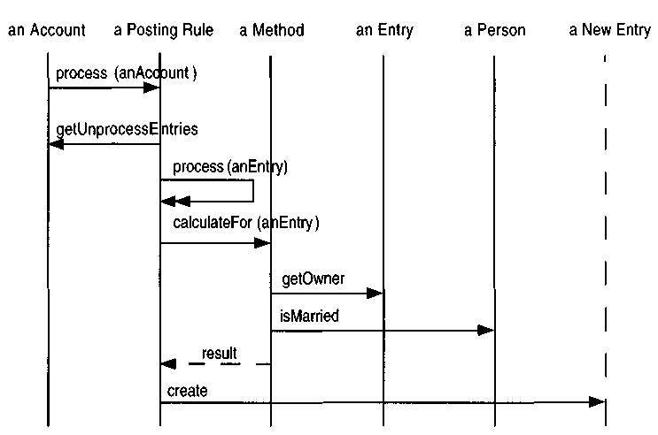

图 6.11 策略模式的使用交互图。

Figure 6.11 Interaction diagram for using the strategy pattern.

该方法通过查询提供的条目来获取所需的任何信息。

The method gets any information it needs by asking the supplied entry.

需要强调的是，此方法对象并非函数式设计（或某些面向对象方法）中意义上的“自由子程序”。该方法被封装在发布规则内部，因为只有发布规则才能引用和使用它。

It should be stressed that this method object is not a "free subroutine," in the manner of functional designs (or some OO approaches). The method is encapsulated within the posting rule, since only the posting rule can reference and use it.

过账规则方法可以在对象之间共享。例如，固定税率方法就是一种共享方法，它应用固定税率并包含一些标准扣除额。如果该方法适用于多种税种，仅税率不同，则可以设计一个方法，该方法向过账规则请求其固定税率，但允许其他处理过程被重用。这种方法可以看作是方法对象和参数化方法（参见 6.6.4 节）实现的结合体。Smalltalk 中这种方法的变体是使用代码块作为方法。这样做可以避免创建新的方法类，并消除方法类的子类。代码块使用起来很优雅，但调试起来可能非常棘手：如果代码块中的代码出现错误，则很难追踪错误原因。但是，如果代码块很简单，这种方法就非常有效。

Posting rule methods can be shared between objects. An example of such a method is the flat tax method, which applies a flat rate of tax with some standard deductions. If the method is the same for several kinds of taxes, with only the rate of tax varying, then a method can be designed that asks the posting rule for its flat rate but otherwise allows the processing to be reused. This method can be seen as a cross between the method object and the parameterized method (see Section 6.6.4) implementations. A variation on this approach in Smalltalk is to use a block as the method. By doing this we eliminate the need for a new method class and eliminate the method class' subclasses. Blocks are elegant to use but can be very tricky to debug: If an error occurs in the block's code, it can be difficult to follow what is going on. If the block is simple, however, this approach can work very well.

##### 6.6.3 使用内部案例陈述进行实施

如果仅仅为了处理一个多态方法就需要创建子类，我们可能会疑惑为什么要这么做。其实，我们可以为过账规则编写一系列私有操作：`computeFederalTax`、`computeMassTax`、`computeSalesCommision` 等等。然后，过账规则上的单个 `computeFor` 操作符包含一个简单的 `case` 语句，根据接收者的实例选择要使用的私有方法，如图 6.12 所示。

Faced with creating subclasses just to handle one polymorphic method, we might wonder why we should bother. Instead we can have a series of private operations for the posting rule: computeFederalTax, computeMassTax, computeSalesCommision, and so on. Then a single computeFor on the posting rule has a simple case statement that chooses which private method to use depending on which instance is the receiver, as shown in Figure 6.12.

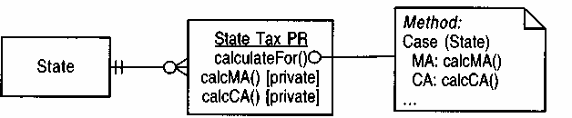

图 6.12 使用内部 case 语句来处理单个实例方法。

Figure 6.12 Using an internal case statement for an individual instance method.

只要 case 语句被 封装在发布规则中，这就不违反面向对象原则。

This is not a violation of object-oriented principles as long as the case statement is encapsulated within the posting rule.

对象设计者往往对使用这种 case 语句的想法感到抵触，但在这种情况下，它却有很多可取之处。修改此实现意味着添加一个新的私有操作，并在 case 语句中添加一个子句。这与策略或单例实现所需的新子类并无太大区别。如果方法数量很多，那么我们就需要一个庞大（但简单）的 case 语句，或者需要大量的子类。因此，这需要在管理大量单例类和每次发布新规则时都必须修改 case 语句之间进行权衡。

Object designers tend to recoil at the idea of using case statements like this, but in this situation there is a lot to be said for it. Modifying this implementation means adding a new private operation and adding a clause to a case statement. This is not much different from the new subclasses required with the strategy or singleton implementation. If the number of methods is large, then we have a large (but simple) case statement, or a large number of subclasses. Thus it is a trade-off between managing a lot of singleton classes and having to change the case statement with each new posting rule.

##### 6.6.4 使用参数化方法的实现

参数化方法策略在过账规则中使用单个方法，并通过基于过账规则或相关类的属性的条件来处理不同的行为。例如，如果所有条目都是固定的百分比，则过账规则可以包含该百分比，并且只需一个计算该百分比的方法即可，如图 6.13 所示。如果某些过账规则对已婚人士和单身人士使用不同的百分比，

The parameterized method strategy uses a single method in the posting rule and handles the different behavior by using conditions based on properties of the posting rule, or of related classes. For example, if all the entries are a flat percentage, then the posting rule can hold the percentage, and a single method that deducts that percentage is sufficient, as shown in Figure 6.13. If some posting rules have different percentages for married and single people,

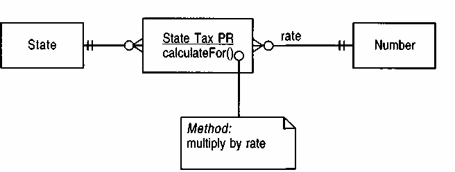

图 6.13 使用参数化发布规则。

Figure 6.13 Using a parameterized posting rule.

然后可以在工资规则中保留已婚和单身两种工资标准，该方法会询问员工的婚姻状况，然后使用相应的工资标准。

then a married and single rate can be held in the posting rule, and the method asks the employee for marital status and then uses the appropriate rate.

如果计算中的所有变化都可以通过改变几个参数来捕捉，那么这种策略是有效的。然而，在这种情况下，我们必须以这种方式建模。只有当情况比这更复杂时，才需要使用单独的实例方法。这是一种潜在的实现方式，因为在某些情况下，我们可以将参数化与其他技术结合起来。

This strategy works if all the variations in the calculation can be captured by varying a few parameters. In such cases, however, we must model it that way. Individual instance methods are only present if the situation is more complicated than that. This is a potential implementation because in some cases we can combine parameterization with another technique.

##### 6.6.5 使用解释器实现

如果方法很简单，我们可以用一种简单的语言将方法表示为一个字符串，并为其构建一个解释器。方法的每个实例都持有其特定的字符串，方法类可以解释该字符串（或许可以使用解释器模式[l]）。

If the method is simple, then we can hold the method as a string in a simple language and build an interpreter for it. Each instance of the method holds its particular string and the method class can interpret the string (perhaps using the interpreter pattern [l]).

适合这种实现方式的方法是使用简单的公式，这些公式只用到算术运算符、括号和几个简单的函数。如果语言本身很简单，那么构建解释器就不会太难。唯一的限制在于该语言能够表达的内容。

Good candidates for this implementation are methods that use simple formulas that use the arithmetic operators, parentheses, and a couple of simple functions. If the language is simple, it is not too difficult to build the interpreter. The only limitation is what can be expressed in the language.

##### 6.6.6 选择实现方式

所有实现方式都运行良好，并且可以隐藏在单个操作背后。如果可以，我会使用参数化方法。我的下一个选择是将参数化方法的实现与其他模式结合使用，看看能否找到一种混合方案，用少量变体方法处理较大的变化，用大量参数处理较小的变化。如果只需要少量变体方法，那么单例模式或内部 case 语句都适用。如果有很多变体，那么策略模式是最佳选择。总的来说，策略模式并不比单例模式或内部 case 语句差多少，但它乍一看可能更难理解。如果方法可以用简单的语言（例如算术公式）来表达，那么使用解释器是个好主意。随着“四人帮”模式的普及，策略模式和参数化方法的组合将成为主流选择。

All of the implementations work well and can be hidden behind a single operation. I use a parameterized method if I can. My next choice is to use the parameterized method implementation in conjunction with one of the other patterns to see if I can find a blend that uses only a few variant methods to handle the larger variations and many parameters to handle the smaller variations. If only a few variant methods are needed, then either singletons or an internal case statement works well. If there are many variants, then the strategy pattern is the best. On the whole the strategy pattern is never much worse than singletons or internal case statements, but it may be a little bit more difficult to understand at first sight. If the method can be expressed with a simple language, such as an arithmetic formula, then the interpreter is a good idea. As the "Gang of Four" patterns become more widespread, a combination of the strategy pattern and a parameterized method will become the dominant choice.

许多建模者可能更倾向于采用图 6.8 所示的其他建模方式。他们或许更喜欢接近其他策略的表达式。如果他们使用同一接口下的另一个实现，仍然可以实现分析与实现的分离。另一些建模者则倾向于采用与实现相同的建模形式。在这种情况下，他们牺牲了实现的独立性，换取了分析模型与实现之间更高的无缝衔接。

Many modelers would prefer another way of modeling the problem than that shown in Figure 6.8. They might prefer an expression closer to one of the other strategies. They can still make the separation of analysis from implementation if they substitute another implementation behind the same interface. Other modelers would prefer to model in the same form as the implementation. In this situation they are trading off implementation independence for a greater seamlessness between analysis model and implementation.

这清楚地表明了区分分析和设计之间的难度。正如软件中各种类的组合可以满足特定的接口一样，我们也可以使用不同的类型组合在概念模型中对同一情况进行建模。类型的选择会影响类的选择。最主要的影响在于，类型的选择定义了类的接口，但接口背后的实际应用未必与概念图景完全一致。

This illustrates clearly the difficulty in drawing a line between analysis and design. Just as various combinations of classes may satisfy a particular interface in software, we may use different combinations of types to model the same situation in conceptual models. The choice of types can influence the choice of classes. The overriding influence is that the choice of types defines the interface of classes, but what lies behind that interface need not match the conceptual picture.

#### 6.7 发布规则执行

#### 6.7 Posting Rule Execution

到目前为止，我们已经了解了发布规则的结构以及它如何响应触发（即执行）指令。现在是时候回顾一下我们可以用来触发发布规则的一些策略了。首先，我想强调的是，发布规则的设计应该使其能够通过不同的方式触发。尽可能地将触发发布规则的策略与规则本身分离至关重要，这样可以降低这些机制之间的耦合性。

So far we have looked at how a posting rule is structured and how it responds to being fired, that is, told to execute. This is a good point to step back and look at some of the strategies we can use to fire posting rules. The first point I want to stress is that posting rules should be designed in such a way that they can be fired by different approaches. It is important to separate the strategy of firing the posting rules from the rules themselves as much as possible to reduce the coupling between these mechanisms.

##### 6.7.1 急于开火

在这种方法中，一旦触发账户中创建了合适的条目，过账规则就会立即触发。我们可以通过两种方式实现这一点。一种是将职责放在事务或条目创建方法中，如图 6.14 所示。创建事务会导致多个条目过账到账户。每个条目的过账都会触发对使用该账户作为触发器的过账规则的搜索。然后，每个被搜索到的过账规则都会被触发。

In this approach posting rules are fired as soon as a suitable entry is made in a trigger account. There are two ways we can do this. One is to put the responsibility in the transaction or entry creation methods, as shown in Figure 6.14. Creating a transaction leads to several entries being posted to accounts. Each posting of an entry prompts a search for posting rules that are using that account as a trigger. Each of these posting rules is then fired.

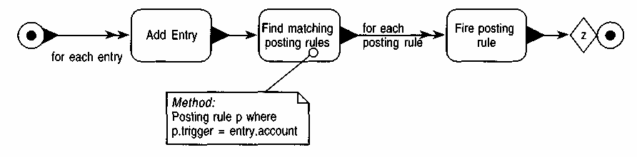

图 6.14 事件图，显示事务创建如何触发过账规则。

Figure 6.14 Event diagram showing how transaction creation can trigger posting rules.

查找和触发过账规则既可以在交易创建期间完成，也可以在单个条目创建方法中完成，如图 6.15 所示。后者是对该过程的更好分解。

The finding and firing of posting rules can be done either during transaction creation or in the individual entry creation methods, as shown in Figure 6.15. The latter is a better factoring of the process.

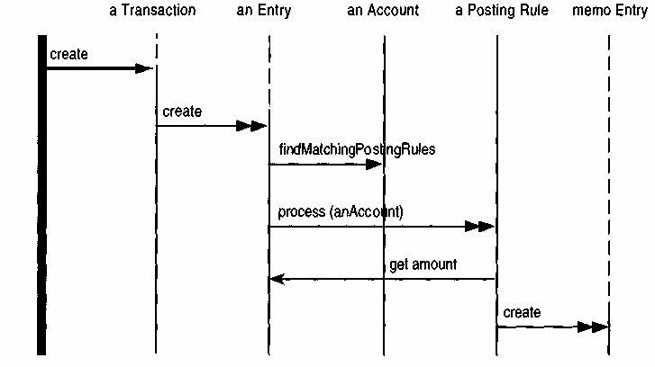

图 6.15 条目创建中触发发布规则的交互图。

Figure 6.15 Interaction diagram for firing posting rules within entry creation.

第二种方法是将过账规则设置为其触发账户的观察者[l]。设置过账规则时，它会将自身注册到触发账户。当账户关联到一条记录时，该账户会向所有观察者广播发生了值得注意的事件。然后，过账规则会查询该账户以了解发生了什么，并发现新的记录。之后，它会在备注账户中生成相应的新记录。这种方案的优点在于，事务不再需要激活过账规则。观察者是一个非常有用的机制，但我通常只在需要确保可见性仅从观察者指向被观察者时才使用它，尤其是在它们位于不同的包中时。我不喜欢在不需要的时候使用观察者，因为过多的观察者会使调试变得困难。我认为我不会将过账规则放在单独的包中，这样就不需要使用观察者了。

A second approach is to make posting rules observers of their trigger account [l]. When a posting rule is set up, it registers itself to the trigger account. When an entry is attached to an account, the account broadcasts to all observers that a noteworthy event has occurred. The posting rule then interrogates the account to find out what has happened and discovers the new entry. It then generates the appropriate new entry to the memo account. The advantage of this scheme is that the transaction no longer needs to activate the posting rule. The observer is a very useful mechanism, but I tend to use it only when there is a need to ensure that visibilities run solely from the observer to the observed, particularly when they lie in different packages. I don't like to use observers when I don't need to, because too many of them make debugging difficult. I don't think I would put the posting rules in a separate package so there is no need to use the observer.

##### 6.7.2 基于账户的解雇

基于账户的触发机制将触发责任从事务转移到了账户。条目可以添加到账户，而无需触发任何过账规则。在某个时间点，账户会被指示进行自身处理，然后触发其出库过账规则，处理自上次自身处理以来到达的所有条目，如图 6.16 所示。

Account-based firing moves the responsibility of firing from transactions to the account. Entries can be added to an account without any posting rules being fired. At some point the account is told to process itself and then fires its outbound posting rules for all entries that have arrived since the last time it processed itself, as shown in Figure 6.16.

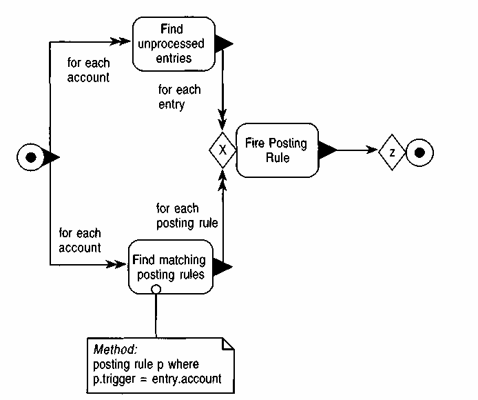

图 6.16 账户的循环触发。

Figure 6.16 Cyclic firing of accounts.

X 表示对过 账规则和未处理条目的每种组合执行火灾过账规则操作。

The X notation indicates that the fire posting rule operation is executed for each combination of posting rule and unprocessed entry.

基于账户的触发机制要求账户跟踪哪些条目尚未处理。它可以通过维护一个单独的未处理条目集合（将条目保存在一个列表中并跟踪最后一个待处理的条目）来实现这一点，或者通过记录上次处理的时间点并返回该时间之后预订的条目（使用“预订时间”属性）。

Account-based firing requires the account to keep track of which entries have not been processed yet. It can do this by maintaining a separate collection for unprocessed entries (keeping its entries in a list and keeping track of the last entry to be processed), or by recording the timepoint of the last process and returning entries that were booked after that time (using the when booked property).

基于账户的触发机制可用于循环会计系统，其中账户每天处理一次。在这种情况下，必须确保账户按正确的顺序处理。必须先处理那些可能受其出站处理规则影响的账户。这些依赖关系可以通过查看处理规则自动确定。

Account-based firing can be used in a cyclic accounting system, where accounts are processed once a day. In this case you must be careful that the accounts are processed in the right order. Accounts must be processed before any accounts that may be affected by their outbound process rules. These dependencies can be determined automatically by looking at the process rules.

##### 6.7.3 基于规则的后触发

在基于过账规则的触发机制中，过账规则由外部代理显式地指示执行。它会检查输入以确定出现了哪些新条目。因此，基于过账规则的触发机制与基于账户的触发机制类似，两者优缺点基本相同。主要区别在于，由于一个账户可以有多个过账规则，因此决定哪些条目尚未处理的责任从账户转移到了过账规则。这通常会使情况更加复杂，所以我更倾向于基于账户的触发机制。

In posting-rule-based firing the posting rule is explicitly told to execute by some external agent. It looks at its inputs to find what new entries have appeared. As such, posting-rule-based firing is similar to account-based firing, with many of the same advantages and disadvantages. The main difference is that since an account can have many posting rules, the responsibility for deciding which entries have not been processed passes from the account to the posting rule. This usually makes the situation more complicated, so I prefer account-based firing.

##### 6.7.4 反向链式发射

反向链式触发是基于账户触发的一种变体：账户不仅处理自身，还会触发所有依赖于它们的账户进行处理。通过这种方法，我们可以掌握任何账户的最新状态。

Backward-chained firing is a variant on account-based firing: The accounts do not just process themselves, and they cause all accounts that they are dependent on to process themselves. With this approach we can discover the up-to-date status of any account.

我们可以首先请求账户提供其条目，如图 6.17 所示。账户首先更新自身。账户使用过账规则来确定哪些账户是触发以自身为输出的过账规则的账户。然后，系统会请求这些账户更新自身，这是一个递归过程，如图 6.18 和 6.19 所示。只需请求最后一个账户进行处理，即可更新整个账户图。

We can start this process by asking an account for its entries, as shown in Figure 6.17. The account first brings itself up to date. The account uses the posting rules to determine which accounts are triggers for a posting rule that has itself as an output. These accounts are asked to bring themselves up to date, which is a recursive process, as shown in Figures 6.18 and 6.19. The whole account graph is brought up to date by simply asking an account at the end to be processed.

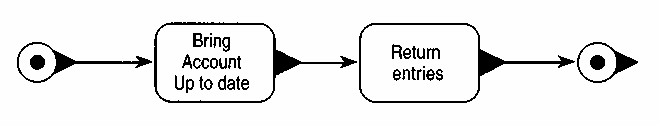

图 6.17 请求对其条目进行详细说明，并反向链接触发。

Figure 6.17 Requesting a detail account for its entries with backward-chained firing.

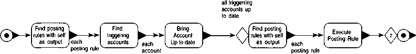

图 6.18 更新账户的方法。

Figure 6.18 Method for bringing an account up to date.

对作为处理账户输入的每个账户递归调用更新账户操作。

The bring account up to date operation is called recursively on each account that is an input for the processing account.

##### 6.7.5 比较不同的射击方式

选择触发方式的主要考虑因素是执行过账规则所需的时间（这是实现决策）以及我们希望在何时捕获错误。立即触发允许我们在发现错误时立即获取错误信息，从而为我们提供更多时间来查找错误原因。但这也迫使我们在创建条目时执行所有计算。基于账户和反向链式触发则为我们提供了更大的计算时间灵活性。如果我们以批处理方式处理账户，我们可以读取所有账户信息。

The primary considerations in choosing a firing approach is the time taken in executing the posting rule (an implementation decision) and the point at which we want to catch errors. Eager firing allows us to get errors as soon as they are found. This gives us more time to find the cause of the errors. It does force us to do all the calculations when we are making entries. Account-based and backward-chained firing give us more flexibility in the timing of calculations. If we process accounts in a batch method, we can read all the

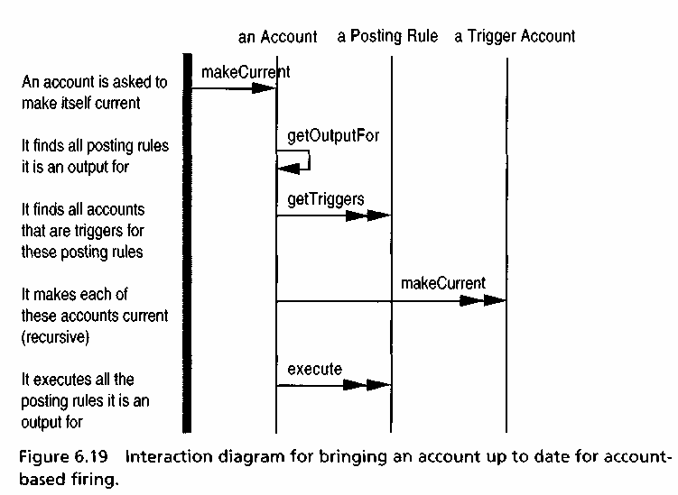

我们可以先从文件中读取条目，然后在方便的时候（比如晚上）触发发布规则。触发得越早，就能越早发现错误。

entries from a file and then fire the posting rules at our leisure, perhaps overnight. The sooner we fire, the sooner we will find any mistakes.

选择基于账户的触发方式还是反向链接触发方式，实际上取决于我们是否愿意承担构建反向链接触发方式带来的额外复杂性。反向链接的构建比基于账户的触发方式更繁琐，但一旦构建完成，使用起来就更加便捷。因此，对于简单的账户结构，我会选择基于账户的触发方式；而对于复杂的账户结构，我会选择反向链接触发方式。总的来说，我不喜欢即时触发，因为它不够灵活。我可以通过确保在添加条目后立即触发记账规则（但不是在创建条目时触发），来获得即时触发的所有优势。虽然这需要额外的步骤，但它允许我根据需要选择不执行此操作。即时触发则不提供这种选择。如果我的处理能力非常强大，以至于记账规则的执行不消耗任何资源，那么这两种方式就没有任何区别了。

Choosing between account-based and backward-chained firing is really about whether we want to handle the extra complexity of building backward-chained firing. Backward chaining is more awkward to build than account-based, but once built it is easier to use. Thus I would use account-based for simple account structures and backward-chained for complex account structures. On the whole I don't like eager firing because it is not as flexible. I can get all the benefits of eager firing by ensuring that posting rules are fired as soon as I add entries (but not as part of entry creation). Although this is an extra step, it does allow me to choose not to do so if I wish. Eager firing does not give me that choice. If I have so much processing power that the posting rules do not cost anything, then it makes no difference.

没有理由不能混合使用不同的触发方式。例如，收益账户可以先使用快速触发的方式将资金投入几层资产账户，然后再使用反向链接的方式继续投入剩余的资金。但是，使用多种触发方案会使系统更加复杂和混乱，因此除非有充分的理由，否则我不会混合使用它们。

There is no reason why you cannot mix the firing approaches. Income accounts might use eager firing into a couple of layers of asset accounts and then use backward chaining for the rest of the way. Using more than one firing scheme will make the system more complex and confusing, however, so I don't mix them unless I have a good reason.

这种方法尚属新兴领域，我们仍在探索各种触发方案的利弊权衡。由于这是一个瞬息万变的领域，保持灵活性至关重要，这样才能在观察系统运行的过程中随时调整触发方案。

This kind of approach is still new, and we are still learning about the trade-offs inherent in the various firing schemes. Since this is such a fluid area, it is important to retain flexibility so that you can change the firing scheme as you watch the system in action.

#### 6.8 多账户发帖规则

#### 6.8 Posting Rules for Many Accounts

到目前为止，我只考虑了我自己和我自己的会计科目表这个比较具体的例子。我们需要将这个例子扩展到更多人的情况。我们希望记账规则保持一致，以便可以使用单一的联邦税务记账规则来确定所有相关人员的联邦纳税义务。

So far I have considered the parochial example of myself and my own chart of accounts. We need to extend this to handle many people. We want the posting rules to be consistent, so that a single federal tax posting rule can be used to determine federal tax liability for all the people involved.

有了这项扩展，就不再存在针对单个账户的过账规则了。每个员工都需要一个独立的账户，但联邦税负过账规则应该能够适用于所有员工。我们不希望为每个员工单独编写过账规则。

With this extension there is no longer a posting rule operating over a single account. Each employee needs a unique account, yet the federal tax liability posting rule should be programmed to work for all employees. We do not want to have to make a separate posting rule for each employee.

我们可以通过两种方式实现这一点。第一种方式是利用知识层和操作层的概念（参见 2.5 节）。我们在知识层设置过账规则，并将其与账户类型关联起来，如图 6.20 所示。这样，我们就可以设置手续费收入、税前利润、净利润等账户类型。出现在账户中的条目会检查其账户类型对应的过账规则，从而有效地为上述表达式增加了一个间接层。

There are two ways we can do this. The first is to use the notion of knowledge and operational levels (see Section 2.5). We set up the posting rules at the knowledge level and link them to account types, as shown in Figure 6.20. Thus we would have account types for fee income, pretax earnings, net earnings, and so on. Entries that appear in accounts check the posting rules on their account type, effectively adding a level of indirection to the kinds of expression discussed above.

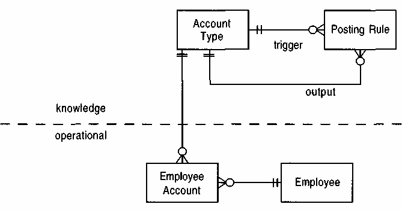

图 6.20 使用账户类型。

Figure 6.20 Using account types.

这引入了一个知识层面，可以基于此定义发布规则。

This introduces a knowledge level on which the posting rules can be defined.

例如，所有员工每工作 18 天即可累积 1 天假期。这可以表示为一条过账规则，其触发账户类型为“工作天数”，输出账户类型为“累积假期”。此方法确保“累积假期”账户余额为“工作天数”余额的 1/18。每次触发员工账户时，系统都会根据所使用的触发类型，查找其账户类型下定义的过账规则。

Example All employees accrue 1 day of holiday for every 18 days worked. This could be represented as a posting rule with a trigger of the account type days worked and an output of the account type accrued holiday. This method ensures that the accrued holidays account balance was 1/18 of the days worked balance. Each time the employee account is triggered, it looks for posting rules defined on its account type according to the type of triggering being used.

然而，知识/运营分离虽然很有吸引力，但并非处理这种情况的唯一方法。第二种方法是使用汇总账户。当任何条目记入汇总账户的任何子账户（或汇总账户本身，如果允许过账）时，在汇总账户上定义的过账规则就会被激活。类似地，也可以在汇总账户上定义输出账户，并解释为这将导致在相应的子账户中产生条目。

However a knowledge/operational split, although appealing, is not the only way of handling this situation. A second approach is to use summary accounts. A posting rule defined on a summary account is activated when any entry is placed into any subsidiary of the summary account (or the account itself, if summary account posting is allowed). The output account can similarly be defined on a summary account with the interpretation that this will cause an entry on the appropriate subsidiary account.

例如，本例中包含工作天数和累计假期汇总账户。过账规则与上述示例相同。不同之处在于，过账规则不再检查账户类型，而是检查汇总账户。

Example In this case there are summary accounts for days worked and accrued holiday. The posting rule is the same as the example above. Instead of checking the account type for posting rules, the summary accounts are checked.

两种方法的选择取决于账户和账户类型之间的差异程度。如果所有记账规则都基于账户类型定义，并且条目都基于账户进行，那么知识/操作分离是合理的。然而，有时情况并非如此。条目可能在更一般的层面上进行，例如用于表示支付给公司的一般费用（这需要图 6.6 所示的模型）。同样，记账规则可能因每笔付款而异：例如，这需要用于支持汽车贷款的扣款。在这种情况下，最好不要进行分离。

The choice between the two methods depends on the degree of difference between account and account type. If all posting rules are defined on account type and entries are made on accounts, then the knowledge/operational split is reasonable. However, sometimes this situation does not occur. Entries can be made at the more general level, perhaps to indicate a general fee to the company (which would require the model shown in Figure 6.6). Similarly, posting rules might vary with each individual payment: This would be required to support deductions for a car loan, for example. When such situations occur, it is better not to make the split.

没有普遍适用的正确方法。在任何特定情况下，都需要确定哪个模型最合适。关键因素是候选账户和账户类型行为差异的程度。

There is no generally correct approach to take. In any given situation it is necessary to see which model provides the best fit. The key factor is the degree of difference in the behavior of the candidate accounts and account types.

无论哪种情况，过账规则都需要确定如何生成正确的输出条目。在上述许多示例中，过账规则只是简单地查找与触发条目属于同一员工的账户。然而，也可能出现更复杂的情况。例如，假设向初级顾问支付费用，导致该费用的一部分被记入该顾问经理的备注账户。在这种情况下，过账规则需要知道如何找到这位经理。

In either case the posting rule needs to determine how to make the correct output entry. In many of the examples above, the posting rule simply looks for the account for the same employee as the triggering entry. More complex situations are possible, however. Consider a situation where a fee entry to a junior consultant causes a percentage of the fee to be posted in a memo account for that consultant's manager. In this case the posting rule needs to be told how to find the lucky manager.

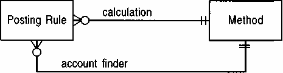

图 6.21 使用账户查找方法。

Figure 6.21 Using an account finding method.

查找输出账户和计算交易价值采用不同的方法 。

Separate methods are used for finding output accounts and calculating the value of the transaction.

处理此问题的一种方法是提供第二种方法来查找合适的输出帐户，如图 6.21 所示。第二种方法会询问原始条目的员工，然后询问该员工的经理。

One way of handling this is to provide a second method to find the appropriate output account, as shown in Figure 6.21. This second method asks the originating entry for its employee and then that employee for its manager.

这样可以提供最大的灵活性，但代价是需要第二个方法对象，该对象必须按照第 6.6 节中的建议进行实现。

This provides the greatest degree of flexibility, at the cost of a second method object, which must be implemented as suggested in Section 6.6.

这暗示了另一个问题。使用通用记账规则时，并非所有员工都符合规则触发的条件。例如，可以设置记账规则来处理每个州的税款。但是，针对伊利诺伊州税款的记账规则只有在员工是伊利诺伊州居民时才应触发。因此，我们提出了第三种方法，用于表达资格条件，如图 6.22 和 6.23 所示。

This hints at another problem. With general posting rules not all employees may be eligible for the posting rule to fire. For example, posting rules can be set up to handle each state tax. A posting rule for Illinois state tax should only fire, however, if the employee is a resident of Illinois. Thus suggests a third method, which is used to express the eligibility condition, as shown in Figures 6.22 and 6.23.

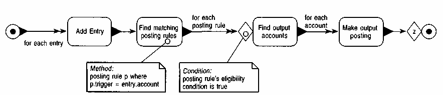

图 6.22 事件图显示了账户查找器和资格条件方法的使用情况，这些方法已添加到图 6.14 中。

Figure 6.22 Event diagram showing the use of account finder and eligibility condition methods added to Figure 6.14.

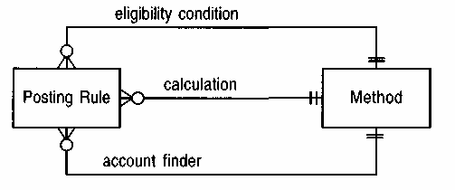

图 6.23 在上述规则中添加资格条件。

Figure 6.23 Adding an eligibility condition to the above rules.

#### 6.9 选择参赛作品

#### 6.9 Choosing Entries

在许多情况下，过账规则需要从其触发账户中选择一部分条目。例如，它可能需要查看自某个特定日期以来的所有条目、7 月份所有已收费条目的余额，或者危险品条目（这将使用某种条目子类型）。执行选择有三种方法：获取所有条目然后进行选择、提供特定于选择的方法以及使用过滤器。

In many situations a posting rule needs to select some subset of entries from its trigger account. It may want to look at all entries since a certain date booked, the balance of all entries charged in July, or entries of dangerous goods (which would use some subtype of entry). There are three ways of performing selections: getting all entries back and then doing a selection, providing a selection-specific method, and using a filter.

第一种方法最简单：账户返回所有条目，客户端处理该集合并选择所需的条目。这种方法无需账户执行任何额外操作，但将所有责任都转移给了客户端。如果许多客户端需要执行类似的选择，则可能会出现大量重复操作。如果条目数量众多，传递集合可能会产生额外的开销，尤其是在需要复制集合的情况下。请记住，账户绝不应传递指向其自身条目存储方式的未保护引用（参见第 14.1 节）。使用这种方法处理条目还意味着客户端需要负责将条目相加以获得余额。

The first technique is the simplest: The account returns all the entries, and the client processes this collection to select the entries it needs. This requires no additional behavior on the account but passes all responsibility to the client. If many clients need to carry out similar selections, a lot of duplication can occur. If there are many entries, there may well be an overhead in passing the set out, especially if the set needs to be copied. Remember that an account should never pass out an unprotected reference to its own way of storing entries (see Section 14.1). Using this approach with entries also means that the client is responsible for summing the entries to get a balance.

如果很多客户都要求进行类似的选择，例如按时间段查询条目，那么可以在账户中添加一个额外的行为来满足这一需求（例如 `entriesChargedDuring(TimePeriod)`）。这样做的好处是可以避免所有客户重复进行相同的选择过程。我们还可以通过提供一个方法来计算一段时间内的余额（例如 `balanceChargedDuring(TimePeriod)`），从而进一步简化客户的操作。但这种方案的缺点是，如果这类选择很多，账户界面就会变得非常庞大。

If many clients are asking for a similar kind of selection, such as entries in a time period, then an additional behavior can be added to the account to satisfy this (such as entriesChargedDuring (TimePeriod)). This has the advantage of saving all the clients from repeatedly going through the same selection process. We can save the clients even more effort by providing a method that gives a balance over a time period (such as balanceChargedDuring (TimePeriod)). The problem with this solution is that if there are many such selections, the account interface grows very large.

过滤器（参见 9.2 节）是一个封装查询的对象。此处使用该模式将生成一个账户过滤器。账户过滤器包含用于设置查询条件的各种操作。过滤器设置完成后，将其应用于账户以获取结果，如图 6.24 所示。账户使用过滤器来选择条目子集，其原理是逐条检查每个条目是否包含在过滤器的 `isIncluded` 方法中。账户可以利用其对条目存储方式的了解来优化此过程。通过这种方法，账户可以使用 `entriesUsing(AccountFilter)` 支持大多数条目选择，并使用 `balanceUsing(anAccountFilter)` 提供相应的余额。请注意，如果条目的子类型具有用作选择依据的其他特征，则可能需要为每种类型的条目创建子类型的账户过滤器。

A filter (see Section 9.2) is an object that encapsulates a query. Using that pattern here would result in an account filter. An account filter includes various operations to set the terms of the query. Once the filter is set up, it is applied to the account to get the answer, as shown in Figure 6.24. The account uses the filter to select the subset of entries by conceptually taking each of its entries and testing it with the filter's isIncluded method. It may apply its private knowledge of how the entries are stored to optimize this process. With this approach the account can support most selections of entries with entriesUsing (AccountFilter) and give corresponding balances with balanceUsing (anAccountFilter). Note that if subtypes of entries have additional features that are used as a basis for selection, then subtypes of account filter may be needed for each type of entry.

对于多值关联，我首先返回所有对象，然后由客户端自行选择。如果有一些常用选项，我会考虑添加额外的行为，但仅限于少数几个。如果选择会导致重复数据过多而无法返回所有对象，但又无法添加太多行为，我会设置一个过滤器。设置和维护过滤器确实需要额外的工作，所以我只在真正需要时才使用它。这种情况经常出现在处理账户及其条目时。

With a multivalued association I start by returning all the objects and leave it up to the client to select them. If there are a few frequently used selections, I might consider using an additional behavior, but only for a few behaviors. If a selection results in too much duplication to return all the objects, but there are too many behaviors to add, I set up a filter. Setting up and maintaining a filter does require extra work, so I use it only when I really need it. This need often appears with accounts and their entries.

#### 6.10 会计实务

#### 6.10 Accounting Practice

当我们遇到一个拥有众多记账规则的大型账户网络时，这个网络就会变得过于庞大而难以处理。在这种情况下，我们需要某种方法将网络拆分成多个部分。以公用事业公司的计费流程为例。他们使用不同的计费流程向不同类型的客户收费。这可以表示为一个账户网络。每种类型的客户都有不同的规则，因此可以使用略有不同的账户网络来处理。

When we run into a large network of accounts with many posting rules, the network becomes too big to deal with. In this situation we need some way to break down the network into pieces. Consider a utility's billing procedures. They bill the various types of customers they have with different billing processes. This can be represented as a network of accounts. Each type of customer has different rules and can be handled with a slightly different network of accounts.

[figure not shown]

图 6.24 使用帐户筛选器的交互图。

Figure 6.24 Interaction diagram for using an account filter.

特定的账户网络构成一个会计实务。从概念上讲，会计实务就是一系列记账规则的集合，如图 6.25 所示。其理念是，每种类型的客户都被分配一个会计实务来处理账单。

A particular network of accounts is an accounting practice. Conceptually an accounting practice is simply a collection of posting rules, as shown in Figure 6.25. The notion is that each type of customer is assigned an accounting practice to handle billing.

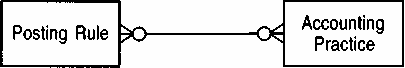

图 6.25 会计实务。

Figure 6.25 Accounting practice.

这些用于将发帖规则分组为逻辑组。

These are used to group posting rules into logical groups.

Example A power utility divides its residential customers into regular and lifeline categories. The lifeline category is for those who the state deems need to be charged minimum rates. The regular customers are divided into three different rate schedules depending on the area in which they live. This is handled by four accounting practices: one for lifeline and one for each of the three areas.

例如， ACM公司有很多工会成员，每个工会都协商不同的协议。ACM公司针对每个工会都有自己的薪酬方案。

Example ACM has many union workers and each union negotiates a different deal. ACM has a pay practice for each union.

同一条记账规则可以存在于多个会计科目中。当不同科目需要类似的操作时，这种情况很常见。我们需要区分从一个科目复制规则（导致两条相同的规则）和在多个科目中使用同一条规则。在多个会计科目中使用同一条规则意味着，当该规则发生更改时，所有使用该规则的科目都会随之更改。而复制规则则允许只更改其中一条规则，而不会影响其他规则。

The same posting rule can exist in more than one practice. This is often the case when similar behavior is needed across practices. We need to be aware of the difference between copying a rule from one practice (leading to two identical rules) and having the same rule in more than one practice. Having a rule in more than one accounting practice implies that when the rule is changed it changes for all practices that use it. Copies allow one copy to change without the others changing.

会计准则被分配给特定的用户对象，以便每个用户都使用唯一的会计准则。例如，电力公司的每个客户或公司的每个员工都使用特定的会计准则。这种分配可以手动完成，也可以通过规则自动确定。

Accounting practices are assigned to some user object so that each user has a single accounting practice. Thus each customer of a power utility or employee of a company uses a particular accounting practice. This assignment can be done manually or a rule can determine it.

例如，在ACM中，工资待遇是根据工人所属的工会来分配的。

Example In ACM the pay practice is assigned to a worker based on his union.

您可以不使用会计实务，而是使用过账规则，根据员工的属性拆分分录。您无需为每个工会使用一种实务，只需使用一种实务即可。第一条过账规则会检查分录所涉员工所属的工会，并为相应的工会账户创建分录（有关此类拆分过账规则的示例，请参见第 7.6 节）。

Instead of using an accounting practice, you can use a posting rule that divides up entries depending on an attribute of the employee. Instead of using one practice for each union, you can use only one practice. The first posting rule looks at the union of the employee that the entry is made for and makes an entry for the appropriate union account (see Section 7.6 for an example of this kind of split posting rule).

如果问题较为复杂，我倾向于使用不同的会计实务，前提是我们可以为用户分配一段时间的会计实务。任何会逐笔更改的拆分（例如第 7.6 节讨论的日间/夜间拆分）都必须有相应的过账规则来处理。如果用户更改了其会计实务，我们可以使用历史映射（参见第 15.3 节）来记录这些更改。

I prefer to use separate practices if the problem is at all complex, providing that we can assign a practice to a user for a period of time. Any splits that always change on an entry-by-entry basis (such as the evening/day split discussed in Section 7.6) must have a posting rule to handle them. If a user changes its accounting practice, we can use a historic mapping (see Section 15.3) to keep a record of these changes.

当不同的处理阶段在逻辑上拥有各自独立的过账规则组时，我们可以将这些规则拆分为不同的业务类型，并为每个用户分配每种类型的业务。如图 6.26 所示，一个会计业务可以拥有用户，这些用户通常可以是任何类型的对象。当然，在特定的模型中，用户可以是客户、员工等等。每个用户都拥有每种类型的一个会计业务，这一约束由键值映射强制执行（参见第 15.2 节）。

When different stages of processing have logically separate clumps of posting rules, we can split the rules up into different practice types and give a user a practice from each type. In Figure 6.26 an accounting practice can have users that can, in general, be any object. In a particular model, of course, users would be customers, employees, or the like. Each user has one accounting practice of each type, a constraint that is enforced by the keyed mapping (see Section 15.2).

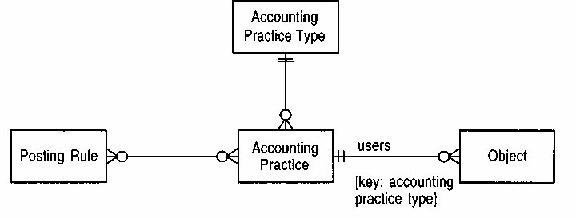

图 6.26 会计实务类型。

Figure 6.26 Accounting practice type.

在较大的账户网络中，我们定义了一种会计实务配置，这种配置会 因使用该配置的每个对象而异。

In larger account networks we define a configuration of accounting practices that vary for each object that uses them.

例如，某公用事业公司针对居民用户采用多种计费方式，但所有居民用户的税费缴纳方式相同。我们可以通过分别制定收费和征税规则来解决这个问题。尽管收费方式不同，但所有居民用户的税费缴纳方式相同。

Example A utility has several practices for billing its residential customers, but all residential customers are taxed the same way. We can handle this by having separate charging and taxing practices. All residential customers have the same taxing practice, although they have separate charging practices.

由此讨论的一个合乎逻辑的结论是，将会计实务和记账规则视为同一整体的组成部分[1]。这样就可以对多个层级的实务进行组合。目前为止，我还没有发现这种做法的迫切需求，因此没有对此进行深入研究。

A logical conclusion to this discussion is to treat accounting practices and posting rules as parts of the same composite [1]. This allows composition of practices for many levels. So far I haven't seen a great need for this, so I have not explored it further.

#### 6.11 条目来源

#### 6.11 Sources of an Entry

了解特定条目的创建原因通常至关重要。例如，如果客户来电咨询某个条目，当前模型可以提供大量关于该条目创建方式的信息。我们可以通过查看其他条目的日期来确定当时的账户状态。我们还可以确定是哪个过账规则计算出了该条目。如图 6.27 所示，该模型可以通过让每笔交易记住是哪个过账规则创建的，以及哪些条目被用作该交易的输入来处理此类客户请求。（如果您不使用交易，则关联关系将逐条条目建立。）

It is often important to know why a particular entry is in the form it is. For example, if a customer calls to ask about a particular entry, the current model can give us quite a lot of information about how the entry was created. We can determine the state of the account at that time by looking at the dates of other entries. We can also determine which posting rule calculated the entry. The model shown in Figure 6.27 can handle such customer requests by getting each transaction to remember which posting rule created it and which entries were used as input for the transaction. (If you are not using transactions, the association runs from entry to entry.)

例如，我因在ACM公司工作而收到2000美元，我将其记录为一笔从手续费收入转入支票账户的交易。我的记账规则在我的纳税义务账户中创建了另一笔交易。这笔交易的创建者是45%的记账规则，其来源是来自手续费收入账户的提款。

Example I received $2000 for some work for ACM, which I recorded as a transaction from fee income to checking account. My posting rule created a separate transaction into my tax liability account. The creator of this transaction was the 45 percent posting rule, and the sources for this transaction contained the withdrawal from the fees income account.

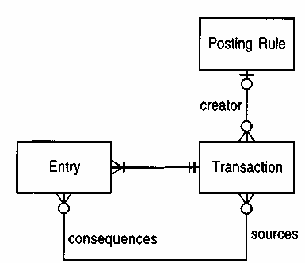

图 6.27 交易的来源。

Figure 6.27 Sources for a transaction.

这将记录每个条目在两个方向上的完整计算过程。

This records a full trail of calculations for each entry in both directions.

利用这种模式，我们可以构建会计结构中一系列条目和交易。每个条目都可以通过递归使用源和结果映射来确定所有原因和结果。

Using this pattern, we can form a chain of entries and transactions across the accounting structure. Each entry can determine all the causes and effects by recursive use of the sources and consequences mappings.

**建模原理**

**Modeling Principle**

*要了解计算结果的原因，可以将计算结果表示为一个对象，该对象会记住创建该结果的计算过程和所使用的输入值。*

*To know why a calculation came out the way it did, represent the result of the calculation as an object that remembers the calculation that created it and the input values used.*

#### 6.12 资产负债表和利润表

#### 6.12 Balance Sheet and Income Statement

在使用账户描述系统时，区分资产负债表账户和损益表账户非常重要，如图 6.28 所示。我的支票账户是资产账户，我的信用卡账户是负债账户。它们反映了我在任何时期拥有的资金（或者，就信用卡而言，是我没有的资金）。这些都出现在我的资产负债表上。收入和支出账户反映了资金的来源和去向。我有一个雇主收入账户，一个储蓄利息收入账户，一个差旅支出账户，一个餐饮支出账户，等等。我的收入和支出账户的余额并不反映我当前拥有的任何资金，而仅仅反映了我对资金来源和去向的分类。

When using accounts to describe a system, it can be worth distinguishing between the balance sheet and income statement accounts, as shown in Figure 6.28. My checking account is an asset account, and my credit card account is a liability account. They reflect the money I have (or in the credit card's case, don't have) at any period of time. These appear on my balance sheet. Income and expense accounts reflect where money comes from or goes to. I have an income account for my employer, another income account for interest from my savings, an expense account for traveling, another for food, and so on. The balances of my income and expense accounts do not reflect any money I currently have, merely my classification of where it comes from and goes to.

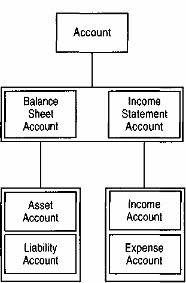

图 6.28 资产、收入和支出账户。

Figure 6.28 Asset, income, and expense accounts.

这些是财务会计中常见的账户类型。这些概念 在其他领域也很有用，可以用来区分持有的资产及其 来源和去向。

These are the kinds of accounts usually found in financial accounting. The concepts are useful elsewhere to distinguish between things held and the classification of where they come from and go to.

账户通常按照一定的模式运作：资金通过收入账户流入，经过多个资产账户流转，最终通过支出账户处置。系统保存的任何资产都会被存放在特定的资产账户中，但许多资产账户仅仅是暂存账户，需要定期进行平衡。负债账户几乎总是需要在某个时间点进行平衡（对于长期债务，例如抵押贷款，这个时间点可能很遥远）。

Accounts are generally used in a pattern where items enter the world via an income account, pass through several asset accounts, and are disposed of via an expense account. Any assets that are saved by the system are kept in particular asset accounts, but many asset accounts are merely staging places intended to be balance regularly. Liability accounts are almost always intended to balanced at some point (which may be far in the future for a long-term debt such as a mortgage).

例如，我用信用卡从波士顿航空公司购买了一张机票。我的信用卡账户是负债账户，而波士顿航空公司的账户是支出账户。这两个账户都由我本人进行分类，我是信用卡账户的持有人（它是我的负债账户）。

Example I buy a ticket from Boston Airlines with my credit card. My credit account is a liability account, and the Boston Airlines account is an expense account. Both accounts are classified by me, and I am the owner of the credit card account (it is my liability).

例如， ACM 从印尼咖啡进口商处购入 3 吨爪哇咖啡豆。ACM 为印尼咖啡进口商设立了一个收入账户，用于记录这 3 吨爪哇咖啡豆从印尼咖啡进口商转入 ACM 位于纽约的账户。该纽约账户是 ACM 拥有的资产账户。

Example ACM buys 3 tons of Java from Indonesian Coffee Importers. ACM has an income account for Indonesian Coffee Importers to record the transfer of the 3 tons of Java from Indonesian Coffee Importers to ACM's New York account. The New York account is an asset account, owned by ACM.

现在我可以简要解释一下为什么我一直避免使用“借方”和“贷方”这两个术语。它们是会计领域常用的术语，但我却选择使用“从”、“到”、“存款”和“取款”来代替它们。原因在于，“借方”和“贷方”在存款和取款的含义上并不总是统一的。对于损益表账户而言，贷方增加账户余额，借方减少账户余额，这对于非专业人士来说很容易理解。然而，对于资产负债表账户而言，借方增加资产（即存款），贷方减少资产。这对于非会计专业人士来说可能有些奇怪，但这却是会计领域的惯例。因此，我避免使用“借方”和“贷方”，部分原因是它们可能会让非会计读者感到困惑，部分原因是我们使用的是比常规财务会计更为抽象的模型。

At this point I can quickly explain why I have avoided the terms debit and credit. These are well-known terms that apply to accounts, yet I have ignored them in favor of from, to, deposit, and withdrawal. The reason is that debit and credit are not used consistently in the sense of deposit and withdrawal. For income statement accounts, credits increase an account and debits decrease it, which makes sense for the layperson. For balance sheet accounts, however, debits increase assets (that is, they are deposits), and credits decrease assets. This may seem strange to nonaccountants, but it is the usual accounting convention. I have thus avoided debit and credit, partly because they might confuse any nonaccountant readers, and partly because we are working with a more abstract model than regular financial accounting.

#### 6.13 对应账户

#### 6.13 Corresponding Account

尽管收入和支出账户是外部账户——钱不是我的——但它们实际上是我的账户，因为我选择了账户的分类。银行对账户的看法就说明了这一点。我有一个支票账户，它是我个人账户系统中的一项资产。银行在其账户系统中也有一个看起来非常相似的账户。银行是该账户的分类者，但我拥有账户内的资产。我们可以将这个账户视为与我个人账户系统中的账户相同，但这并不合理。例如，我可能在3月1日记入一笔ATM取款的账目，因为那天是我取款的日期。银行则在3月2日记入同一笔取款，因为那是银行的下一个工作日。这两个账户都指向同一资产，但它们并不相同，因为它们的账目记录不同。更好的做法是将这两个账户视为对应账户。

Although income and expense accounts are external—the money is not mine—they are my accounts in that I choose the classification. The bank's view of accounts illustrates this. I have a checking account that is an asset within my personal system of accounts. The bank has an account within its system of accounts that looks remarkably similar. The bank is the classifier of the bank's account, but I own the assets within it. We could consider this the same account as the one in my system of accounts, but this would not work. I might post an entry for an ATM withdrawal on March 1, which is the day I made the withdrawal. The bank posts the same withdrawal on March 2 because that is the next working day at the bank. The two accounts both refer to the same asset, but they are not the same because their entries differ. It is better practice to consider the two accounts as corresponding.

相应的账户理应在某种程度上保持一致，并且通常会在某个时间点进行对账。例如，当我将支票簿（我的账户）与银行对账单（银行的账户）进行核对时，就会发生这种情况。对账过程可能非常精确，也可能允许存在一些误差，例如日期上的细微差别。

Corresponding accounts are expected to match in some way and are usually reconciled at some point. This is what happens when I match my checkbook (my account) against the bank statement (the bank's account). The reconciliation process may be precise, or it may allow some imprecision, such as slight differences in dates.

图 6.29 展示了这种情况。只有余额账户才有所有者；损益表账户没有资产，因此不存在所有权问题。所有账户都有一个分类器来指示账户的创建者和操作者；我使用了“参与方”（参见 2.1 节）。对应关系展现出几个特殊属性：对称性和传递性 [3]。首先，它是对称的：如果账户 x 是账户 y 的对应账户，那么账户 y 也必须是账户 x 的对应账户。通常情况下，关联的默认属性是不对称的。传递性表明，如果账户 y 是账户 x 的对应账户，且账户 z 也是账户 y 的对应账户，那么账户 z 也是账户 x 的对应账户。

Figure 6.29 illustrates this situation. Only balance accounts have owners; income statement accounts do not have assets so there is no question of ownership. All accounts have a classifier to indicate who creates and manipulates the accounts; I have used party (see Section 2.1). The correspondents relationship shows a couple of special properties: symmetry and transitivity [3]. First it is symmetric: If account x is a correspondent of account y then account y must be a correspondent of account x. The usual default for associations is that they are asymmetric. Transitivity indicates that if account y is a correspondent of account x and account z is a correspondent of account y, then account z is a correspondent of account x.

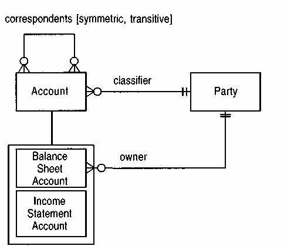

图 6.29 对应账户。

Figure 6.29 Corresponding accounts.

#### 6.14 专业账户模式

#### 6.14 Specialized Account Model

我提供了几个例子来说明该模型可以作为财务会计和库存跟踪的基础。会计模型通常会进行子类型划分，以便提供特定领域的信息。例如，考虑库存管理——这是一个适合使用账户的问题。我们可以为每种商品种类和存放地点的组合创建一个账户（并赋予它一个不太专业的会计名称，例如“持有”）。

I have provided several examples to show that this model can be used as a basis for both financial accounting and inventory tracking. With the accounting models it is usual to subtype to provide the information for the particular domain. For example, consider inventory management—a problem suited to the use of accounts. We can form an account for each combination of kind of goods and location (and give it a less accounting name, such as holding).

因此，如果我们追踪麦卡伦、泰斯卡和拉弗格威士忌在伦敦、巴黎和阿姆斯特丹之间的流转，我们将拥有九个资产账户（例如伦敦-麦卡伦、伦敦-泰斯卡、巴黎-泰斯卡等等）。每当我们将货物从一个地点转移到另一个地点时，我们都会创建一个转移（交易）来记录这一转移。与货币一样，转移必须保持平衡。此外，在整个转移过程中，货物的种类必须保持一致。图 6.30 展示了这种账户模型的扩展。

Thus if we are tracking bottles of Macallans, Talisker, and Laphroig whiskey between London, Paris, and Amsterdam we would have nine holdings (asset accounts, such as London-Macallans, London-Talisker, Paris-Talisker, and so on). Whenever we move goods from one location to another, we create a transfer (transaction) to handle the movement. As with money, transfers have to balance. In addition, the kind of object must be the same throughout the movement. Figure 6.30 shows this kind of extension to the account model.

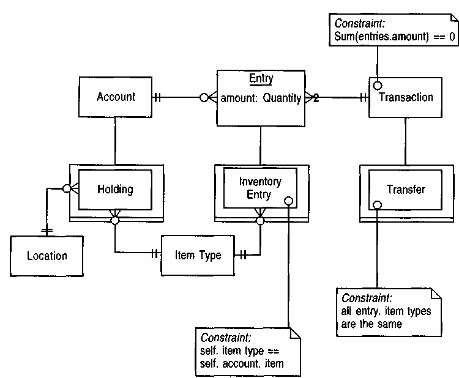

图 6.30 专门化账户模型以支持库存。

Figure 6.30 Specializing the account model to support inventories.

这种专业化是为了将会计模型应用于特定 领域。

This kind of specialization should be done to use the accounting model in a particular domain.

这种方法也适用于追踪订单，包括收发货。每个供应商都会有一个收入账户，如果供应商所在地很重要，则可能需要多个账户。同样，每个客户都会有一个支出账户。我们可以通过两种方式追踪订单：我们可以允许转账的子类型，例如已订购或已实际；或者我们可以为订单提供另一组库存，例如，我们可以有“伦敦-泰斯卡-已订购”和“伦敦-泰斯卡-已实际”。当订单生成时，我们会将资金从供应商的已订购库存转移到我们要求交付地点的已订购库存。当订单交付时，我们会将资金从已订购库存转移到我们所在地的已订购库存。这与在财务账簿中使用应收账款账户完全相同。

This approach could also work to track orders, both incoming and outgoing. Each supplier would have an income account, perhaps more than one if supplier location was important. Similarly each customer would get an expense account. We can track orders in two ways: We could allow subtypes of transfer, either ordered or actual, or we could provide another set of holdings for orders, so we would have, for example, London-Talisker-Ordered and London-Talisker-Actual. When an order is placed, we would make a transfer from a supplier ordered holding to the ordered holding at the location we want it delivered. When the order is delivered, we would make the transfer between the ordered holding and the actual holding at our location. This is exactly the same as using a receivables account in financial books.

我们可以使用持仓汇总来了解整体情况。所有已订购持仓的汇总持仓可以得出已订购持仓的总数量，而泰斯卡（Talisker）的汇总持仓则可以得出所有地点泰斯卡的总数量。

We can use summary holdings to get an overall picture. A summary holding of all ordered holdings can give the total ordered position, and a summary holding of Talisker gives the total amount of Talisker in all locations.

#### 6.15 记账分录到多个账户

#### 6.15 Booking Entries to Multiple Accounts

处理账户时，一个常见的问题是需要将同一笔款项记入多个账户。例如，假设我花了 500 美元购买机票参加 OOPSLA 会议。我应该将这笔费用记入 OOPSLA 账户（以便计算参加 OOPSLA 的总成本），还是记入机票账户（以便计算机票支出）？处理这种情况有几种方法，这些方法不仅能说明使用账户的一些要点，还能展示比前面提到的简单账户层级结构更复杂的账户结构。

A common problem in dealing with accounts is when there is more than one place to book an entry. For example, suppose I paid $500 for my airline ticket to attend the OOPSLA conference. Do I book this to an OOPSLA account (so that I can work out how much it cost me to attend OOPSLA) or to an air travel account (so that I can work out how much I spent on air travel)? There are several ways to handle this, which illustrate some useful points about using accounts and also illustrate more complex account structures than the simple account hierarchies mentioned earlier.

一份典型的咨询账单就能说明这个问题。假设我为ACM公司提供了三天的咨询服务，收费6000美元。此外，我还产生了一些费用：机票500美元，酒店250美元，租车150美元，餐费100美元。我该如何核算这些费用？更准确地说，如果我有一个完善的会计系统，我该如何核算这些费用？显然，我需要为ACM公司设立一个账户，以便向他们开具账单。然而，一个账户是不够的。我更关心的是我从各个客户那里赚了多少钱。在进行这项分析时，我不想看到这些费用，因为它们并非收入。同样，我的纳税义务估算也需要忽略这些费用。这意味着我可以分别设立ACM公司费用和ACM公司支出账户。我的ACM账单就是由这两个账户的汇总账户构成，如图6.31所示。但问题在于，我需要一个单独的账户来记录所有已赚取的费用。此费用账户将包含ACM费用、Megabank费用和其他客户费用。它也可以用作汇总账户，但这违反了图6.5和图6.6所示的层级结构限制。因此，我需要修改模型，允许一个明细账户拥有多个汇总账户作为其父账户，如图6.32所示。

A typical consultant's bill illustrates the problem. Let's say that I do three days' consultancy for ACM. I charge them $6000 for the work. In addition, I run up some expenses: $500 for the air fare, $250 for the hotel, $150 for car rental, and $100 for meals. How do I account for this, or more precisely, how do I account for this if I have a decent accounting system? Clearly I need an account for ACM so that I can send them a bill. However, one account is not enough. I am interested in seeing how much I earn from various clients. When I do this analysis, I do not want to see the expenses because they are not earned money. Similarly my tax liability estimates also need to ignore expenses. This indicates that I could use separate accounts for ACM fees and ACM expenses. My ACM bill is then formed by a summary account over these two accounts, as shown in Figure 6.31. The problem with this is that I need a separate account for all earned fees. This fee account would include accounts for ACM fees, Megabank fees, and other clients' fees. This also works as a summary account, but it breaks the hierarchical restriction of Figures 6.5 and 6.6. Thus I need to alter the model to allow a detail account to have multiple summary accounts as parents, as shown in Figure 6.32.

图 6.32 中的模型允许账户构成有向无环图。因此，一个账户可以有多个父账户，但我们避免了循环（一个账户不能是它自己的祖账户）。这种结构允许存在多个汇总账户。

The model in Figure 6.32 allows the accounts to form a directed acyclic graph. Thus an account can have many parents, but we avoid cycles (an account cannot be its own grandparent). This structure allows multiple summary accounts.

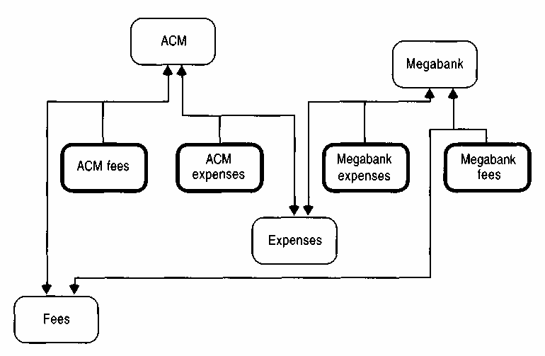

图 6.31 典型的费用/支出账户结构。

Figure 6.31 A typical fee/expense account structure.

带粗边框的图标是详细信息，其概要如箭头所示。

The heavy bordered icons are detail accounts, summarized as shown by the arrows.

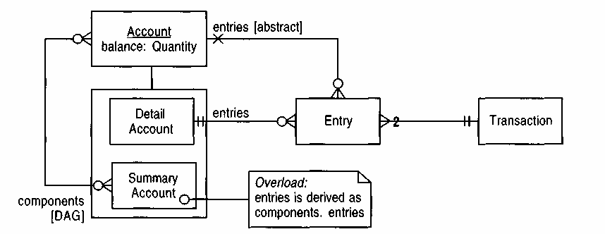

图 6.32 允许多个汇总账户。

Figure 6.32 Allowing multiple summary accounts.

该图用有向无环图代替了图 6.5 的层次结构。

This diagram replaces the hierarchy of Figure 6.5 with a directed acyclic graph.

然而，这里有一个小问题需要考虑。如果我的账户结构如图 6.33 所示，会发生什么情况？账户 X 包含了 ACM 和费用，因此 ACM 费用账户会被计算两次。

However, there is a small wrinkle that we must consider. What would occur if I had the account structure of Figure 6.33? The account X sums over ACM and fees, so the ACM fees account gets counted twice.

根据图 6.32 中的模型，我们仍然可以得到 X 的正确余额。余额是基于一组派生的条目定义的。集合本身并不……

According to the model in Figure 6.32, we would still get a correct balance for X. The balance is defined on a derived set of entries. Sets do not

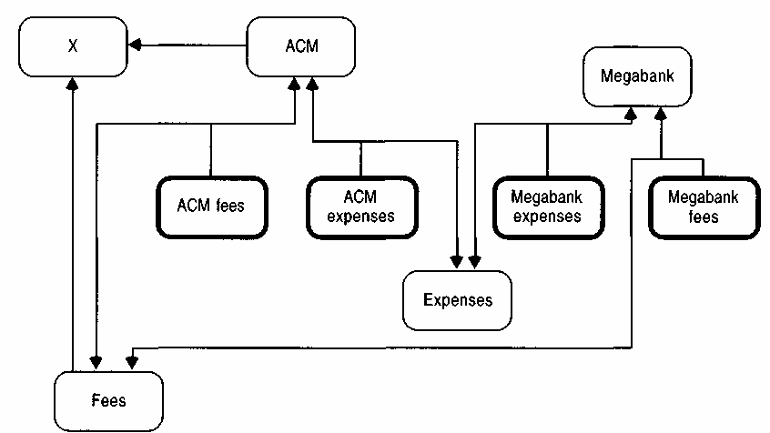

图 6.33 账户结构凸显了一个问题。

Figure 6.33 Account structure that highlights a problem.

如果使用多个汇总账户，则有人可能会定义一个汇总账户，该汇总账户与 明细账户重叠。

If multiple summary accounts are used, someone could define a summary account that has overlapping detail accounts.

允许重复项，因此 ACM 费用中的所有条目在 X 中只会出现一次，从而确保 X 的余额正确。然而，此余额并不等于费用和 ACM 余额之和，这可能会造成混淆。如果这种混淆确实存在，我们需要对组件关系施加约束，禁止选择任何存在重叠的组件。这是一个合理的约束，因为很难找到 X 这种账户的实用示例。定义此类账户更有可能是偶然的产物，而非刻意设计。

allow duplicates, so all the entries in ACM fees will only appear once in X, thus giving us a correct balance for X. However this balance will not be equal to the sums of the balances for fees and ACM, which might prove confusing. If this confusion is a problem, we need a constraint on the components relationship that would not allow us to select components that had any overlap. This is a reasonable constraint since it is difficult to come up with an example where such an account as X would be useful. Defining this kind of account is more likely to be the product of accident than design.

##### 6.15.1 使用备忘录条目

该模型目前运行良好，但需考虑一些细节。可能需要更详细地细分支出。税法可能要求我们将差旅、住宿和餐饮支出分开列示（例如，ACM-机票、ACM-住宿、Megabank-机票等等）。虽然可以通过将每个支出账户细分为多个子账户来实现，但由于账户组合复杂，管理起来可能会比较困难。因此，值得探索其他方案。

The model works well at this level, but consider some further details. There may be a need to break down expenses in more detail. Tax regulations may require us to separate expenses for travel, lodging, and meals (for example, ACM-airfare, ACM-lodging, Megabank-airfare, and so on). This could be done by breaking each expense account into detail accounts, but this could become difficult to manage due to all the complex combination accounts. It is worth exploring some other options.

一种方法是使用备注账户记账。例如，一张价值 500 美元的 ACM 总部访问机票，需要同时记入 ACM 费用账户和机票账户。这种方法无需单独设立 ACM 机票账户，但需要额外的记账分录。虽然过账规则可以在一定程度上解决这个问题，但我们仍然需要明确指定需要记入哪个费用账户。这可以通过创建特殊的费用交易来实现，该交易需要指定“来源账户”、“目标账户”和“费用类型（备注账户）”等参数。

One option is to use entries into memo accounts. Thus $500 for a ticket to visit ACM headquarters would result in depositing into both the ACM expenses account and an airfare account. This method removes the need for an ACM-airfare account but requires additional entries. A posting rule might deal with this to some extent, but we still need some statement about which expense account is needed. This might be done by a special expense transaction creation that takes parameters of from account, to account, and expense type memo account.

选择将 ACM 费用账户还是机票账户设为备注账户，取决于账户的后续用途。如果 ACM 费用账户用于追踪发票付款情况，而机票账户仅用于税务申报，那么机票账户更适合作为备注账户。与使用备注账户相比，选择哪些账户存放主要资金流存在一定的随意性。

Choosing whether the ACM expense account or the airfare account should be a memo account depends on subsequent use of the account. If the ACM expense account is being used to track the payment of invoices, while the airfare account is only being used for tax reporting, then the airfare account would make the better memo account. There's a certain amount of arbitrariness in choosing which accounts hold the main stream of money, compared to those working with memo accounts.

##### 6.15.2 衍生账户

另一种方法是使用派生账户，如图 6.34 所示。在这种情况下，条目是通过为派生账户提供一个筛选器（参见 6.9 节）来指定的，该筛选器会选择匹配的条目。为了正常工作，派生账户需要一个可以作为其派生基础的对象。支持费用类别的条目子类型就是一个很好的选择，然后创建一个成员资格测试为“费用类别 = 机票”的账户，即可生成所需的信息。

A different approach is to use a derived account, as in Figure 6.34. In this case the entries are specified by providing the derived account with a filter (see Section 6.9), which selects matching entries. To work, the derived account needs something on which to base its derivation. A subtype of entry that supports an expense category would do nicely, and then an account where the membership test is expense category = airfare would create the desired information.

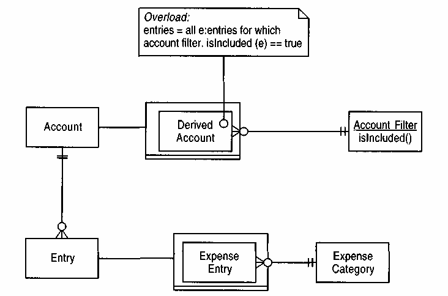

图 6.34 引出账户。

Figure 6.34 Introducing derived accounts.

我们可以考虑进一步拓展这种方法。为什么不完全放弃使用账户，而采用类似图 6.35 的方式呢？这样，我们只需查询费用就能了解情况了。

We might consider taking this approach further. Why not abandon using accounts altogether and just have something like Figure 6.35? We can then work out what is going on just by queries on expense.

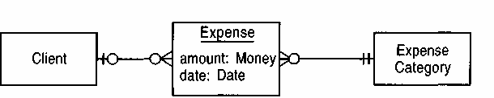

图 6.35 费用定义放弃会计模型。

Figure 6.35 Expenses defined to abandon the accounting model.

派生账户仍然可以让我们使用所有报告行为，但我们会失去 跟踪行为。

A derived account can still allow us to use all the reporting behavior, but we lose the tracking behavior.

这个问题有助于解释账户的用途以及衍生账户的价值。账户在相对静态的结构中最为有效，尤其是在需要追踪复杂的资产流动时。如果流动很简单，例如只是将费用分配给机票，那么账户就不是必需的。但是，假设我在同一趟旅行中同时访问了Megabank和ACM，并将三分之二的机票费用记入其中一家，三分之一记入另一家。这种多方交易正是账户能够很好地处理的。然而，图6.35中的模型在处理这种情况时存在一个实际问题。我该如何以这种方式拆分一笔简单的付款呢？请注意，图6.35中的模型还存在另一个问题：它没有说明资金来源。我可以添加信用卡关联，但这样一来，费用看起来就非常类似于两方交易了。

This question helps define why accounts are useful and why derived accounts are valuable. Accounts work best within relatively static structures where complex movements of assets need to be tracked. If the movements are simple, such as just assigning an expense to airfare, then accounts are not really needed. However, consider the situation where I visit both Megabank and ACM in one trip and charge two-thirds of the airfare to one and one-third to the other. This is the kind of multilegged transaction that accounts handle well. However, the model in Figure 6.35 has a real problem with this. How do I split a simple payment up in this way? Note that the model in Figure 6.35 has another problem: It does not say where the money comes from. I could add a credit card association to it, but then expense looks very similar to a two-legged transaction.

当账户结构并非十分固定时，使用属性创建派生账户非常有效。如果存在多种信息切入点，派生账户可以利用账户本身的报表功能轻松计算这些信息。然而，派生账户仅限于报表功能，无法进行过账，因此不能用于跟踪资产的变动。

Using attributes for derived accounts is effective when the account structure is not very static. If there are many possible cuts of information, then the derived account allows these to be computed easily using the same reporting facilities that accounts have. However, they only have the reporting facilities. Derived accounts cannot be posted to and thus cannot be used to track the ebb and flow of assets.

因此，每当我们试图表示某个条目的某个方面时，我们可以在条目的属性和新的账户层级之间进行选择。具体选择取决于您需要账户行为的哪一部分。如果仅仅是报表方面，我们可以使用属性，并在需要时派生出一个账户。否则，就需要一个新的账户层级。

So whenever we are trying to represent an aspect of an entry, we have a choice between an attribute of the entry or a new account level. The decision is based on what part of the account behavior you need. If it is simply the reporting side, we can use an attribute and derive an account when it's needed. Otherwise, a new level of accounts is required.

#### 延伸阅读

#### Further Reading

我可以推荐一些其他的会计资料，它们能提供与本章不同的视角。Hay [2] 专门有一章讲解会计。他对账户和交易的基本概念与我的非常相似，尽管他没有介绍过账规则。他对公司中存在的账户类型进行了更深入的探讨。他还讨论了公司中常用的交易类型以及它们如何融入会计模型。此外，他还给出了这些账户和交易类型的知识水平要求。

I can recommend a couple of other sources for information on accounts that will give a different perspective to that presented in this chapter. Hay [2] has a chapter dedicated to accounting. His basic concepts of accounts and transactions is very much the same as mine, although he does not present anything on posting rules. He goes into much more depth on the account types that are present in corporations. He also discusses the common transactions that are used in corporations and how they fit into this accounting model. He also presents a knowledge level for these account and transaction types.

伊利诺伊大学厄巴纳-香槟分校在开发会计框架方面做了大量工作[4]。¹ 这与我和Hay的方法截然不同。它首先将发票上的信息（例如）视为针对高层账户的高层“交易”。然后，可以将此“交易”分解为针对低层账户的低层“交易”。他们对“交易”一词的使用与我截然不同：他们不遵循守恒原则。高层“交易”可能是一张包含所有明细项目的发票。该框架的重点在于将其分解为低层“交易”，例如明细项目本身。因此，该框架旨在将一组条目分解为其组成条目，而不是像我那样，构建一个账户网络及其之间的转账关系。

There has been a lot of work at the University of Illinois at Urbana-Cham-paign on developing an accounting framework [4].1 This takes a very different approach to Hay and myself. It starts with treating the information on an invoice (for example) as a high-level "transaction" against a high-level account. This "transaction" can then be broken down to lower-level "transactions" against lower-level accounts. They use the word transaction very differently than I do: They do not follow the principle of conservation. A high-level "transaction" might be an invoice with all its line items. The framework concentrates on breaking this down into lower-level "transactions," such as the line items themselves. Thus the framework is designed to break down a cluster of entries into its component entries, rather than my approach of a network of accounts and transfers between them.

#### 参考

#### References

1. Gamma, E.、R. Helm、R. Johnson 和 J. Vlissides。《设计模式：可重用面向对象软件的要素》。马萨诸塞州雷丁：Addison-Wesley，1995 年。
2. Gamma, E., R. Helm, R. Johnson, and J. Vlissides. Design Patterns: Elements of Reusable Object-Oriented Software. Reading, MA: Addison-Wesley, 1995.
3. Hay, D. 数据模型模式：思维惯例 纽约，纽约州：多塞特出版社，1996 年。
4. Hay, D. Data Model Patterns: Conventions of Thought New York, NY: Dorset House, 1996.
5. Langer, SK，《符号逻辑导论》，第三版。纽约：多佛出版社，1967 年。
6. Langer, S.K. An Introduction to Symbolic Logic, Third Edition. New York, NY: Dover, 1967.
7. Keefer, PD 会计系统的面向对象框架。伊利诺伊大学厄巴纳-香槟分校 <ftp://st.cs.uiuc.edu/pub/Smalltalk/st80_vw/ accounts/thesis.ps>，1994 年。
8. Keefer, P.D. An Object-Oriented Framework for Accounting Systems. University of Illinois at Urbana-Champaign <ftp://st.cs.uiuc.edu/pub/Smalltalk/st80_vw/ accounts/thesis.ps>, 1994.
9. Meyer, B.“应用‘合同设计’”，IEEE计算机，25，10（1992），第40-51页。
10. Meyer, B. "Applying 'Design by Contract,'" InlEEE Computer, 25, 10 (1992), pp. 40-51.

请参阅 http://st-www.cs.uiuc.edu/users/johnson/Accounts.html

See http://st-www.cs.uiuc.edu/users/johnson/Accounts.html

[figure not shown]

### 第七章 会计模型的应用

### Chapter 7. Using the Accounting Models

要充分理解本章内容，您需要先阅读第六章。本章与本书其他章节有所不同。它并非描述一系列模式，而是展示如何运用第六章中介绍的模式。这并非易事，因为第六章中的会计模式相当抽象。为了真正理解这些模式的运作方式，我们需要参考一个完整的示例。

To fully understand this chapter, you will need to read Chapter 6 first. This is an unusual chapter in this book. Instead of describing a group of patterns, this chapter shows how we can use the patterns presented in Chapter 6. This is a difficult task because the accounting patterns in Chapter 6 are quite abstract. To understand how the patterns really work, we need to look at a fully worked example.

本章探讨了电信公司 Total Telecommunications (TT) 模型中使用的账户和记账规则。秉承教科书的优良传统，本章提供的示例较为简化，但足以让您大致了解模型的工作原理。本章旨在说明账户模型的用法，而非构建一个完整的电信公司模型。

This chapter looks at accounts and posting rules used in a model for a telephone utility, Total Telecommunications (TT). In the best textbook tradition, the examples presented here are somewhat simplistic. They should be sufficient to at least give you a feel for how the models work. The aim is to illustrate the use of the account model, not to model a telephone company.

由于本章为示例章节，我使用了一些代码来说明示例。我选择 Digitalk Smalltalk 而不是 C++，是因为 Smalltalk 更容易让我传达基本概念。这些概念应该很容易移植到 C++。我在转换模型时使用了第 14 章中的模式。我还参考了 Kent Beck 的编码模式 [1]，并做了一些修改。我必须强调，我没有尝试优化代码。此外，我没有提供完整的代码，只做了重点标注。

Since this is an example chapter, I have used some code to illustrate the examples. I chose Digitalk Smalltalk over C++ because Smalltalk makes it easier for me to convey the basic ideas. The concepts should be readily trans-ferable to C++. I have used the patterns from Chapter 14 in transforming the models. I have also used Kent Beck's coding patterns [1], with some variations. I must stress that I have made no attempt to optimize the code. I also have not provided complete code, only highlights.

为了简单起见，我省略了跨越边界的呼叫情况。

For the sake of simplicity, I have skipped the case of calls crossing the boundary.

本章首先讨论结构模型（7.1），该模型自然基于第6章中介绍的模式。接下来，我们将探讨实现该结构的一些有趣特性（7.2）。为了设置对象，我们首先设置新的电话服务（7.3），然后设置呼叫（7.4）。之后，我们初步了解记账规则，并检查实现基于账户的触发机制的代码（7.5）。本章给出了三个记账规则示例：将呼叫分为白天和晚上（7.6）、按时间计费（7.7）以及计算税费（7.8）。每个规则都展示了行为的特定方面。前两个规则逐条操作，并且使用一个公共超类型——每个条目记账规则——来处理通用行为。将费用分为白天和晚上则由每个条目记账规则的简单单例子类型来处理。白天和晚上的呼叫需要不同的规模，但由于基本流程相同，我们可以使用由费率表参数化的策略对象。这使我们能够处理任何根据通话时长按一定比例收费的记账规则。用作策略对象的费率表类可以用于任何基于通话时长的计算。实际上，它被用于下一个计算税费的记账规则。与之前的规则不同，此规则必须按月运行，但我们不能假设它每月运行一次。

The chapter begins with a discussion of the structural models (7.1), which is naturally based on the patterns presented in Chapter 6. We then look at some interesting features of implementing the structure (7.2). To set up the objects, we begin by setting up new phone services (7.3), followed by setting up calls (7.4). We then take a first look at the posting rules, examining the code for implementing account-based firing (7.5). Three example posting rules are given: separating calls into day and evening (7.6), charging for time (7.7), and calculating the tax (7.8). Each rule illustrates a particular aspect of behavior. The first two rules operate on an entry-by-entry basis, and a common supertype—each entry posting rule—handles the common behavior. Splitting charges into day and evening is handled by a simple singleton subtype of each entry posting rule. A different scale is required for day and evening calls, but since the basic process is the same, we can use a strategy object parameterized by a rate table. This allows us to handle any posting rule that charged according to some scale based on the length of the call. The rate table class used as the strategy object can be used for any calculation based on lengths in this way. Indeed it is used for the next posting rule that calculates tax. Unlike the prior rules, this rule has to work on a month-by-month basis, but we cannot assume it is run once per month.

这三个过账规则类应该能很好地说明我们如何使用账户/库存模式来显示货币交易和非货币交易。

The three posting rule classes should give a good idea of how we can use the account/inventory patterns to show both monetary and nonmonetary transactions.

在代码开发过程中，我喜欢先构建结构模型的框架。然后我会制作原型，并注意在开发过程中不断更新结构模型（否则我可能会忘记自己做到哪一步了）。遇到棘手的行为时，我可能会在编程初期或过程中使用事件图或交互图。如果我认为记录我对这些行为的处理方式很重要（就像我在这本书中所做的那样），我会在代码整理完毕后绘制图表。这些图表并非代码的替代品；它们有助于阐明代码的功能。（当然，如果使用合适的工具，事件图也可以直接作为代码使用。）

In developing code I like to begin with building the skeleton of the structural model. I then prototype, being careful to update the structural model as I go (otherwise, I can forget where I am). As tricky behaviors come up, I may use event diagrams or interaction diagrams at the start or during the programming. If I think it is important to document what I have done with these behaviors (as I do for this book), I produce diagrams once I have the code sorted out. The diagrams are not replacements for the code; they help to illustrate what the code is doing. (With a suitable tool, however, event diagrams could be used as the code.)

#### 7.1 结构模型

#### 7.1 Structural Models

最好的切入点是结构模型，因为它们能概览最终模型的各个组成部分。图 7.1 展示了模型中的各个模块。我将模型分为两个模块：电话服务和账户。会计框架的一个优点是它可以应用于不同的行业，因此我们需要确保会计模型与任何行业特定概念完全分离（即，不受任何行业特定概念的影响）。

The best place to start is with the structural models because they give an overview of the various pieces of the final model. Figure 7.1 shows the packages within the model. I've split the model into two packages: phone service and account. One virtue of an accounting framework is that it can be used for different industries, so we need to ensure that the accounting model is kept separate from (that is, has no visibility to) any industry-specific concepts.

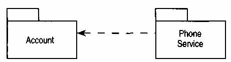

图 7.1 TT 示例的软件包。

Figure 7.1 The packages for the TT example.

账户包包含抽象的会计类型， 电话服务包针对此特定域扩展了这些类型。

The account package holds the abstract accounting types, which are extended by the phone service package for this specific domain.

图 7.2 展示了基于第 6 章模式的 TT 会计模型。该模型包含从过账规则到账户的三重关联。触发器和输出是常见的，但键值输出是新增的。这使得需要多个输出账户的过账规则可以拥有多个输出账户。本章后续的示例将阐明其必要性。

Figure 7.2 shows the accounting model for TT, based on the patterns from Chapter 6. This model has three associations from posting rule to account. Trigger and output are familiar, but the keyed output is new. This allows multiple output accounts for those posting rules that need them. The need will become clear with examples later in the chapter.

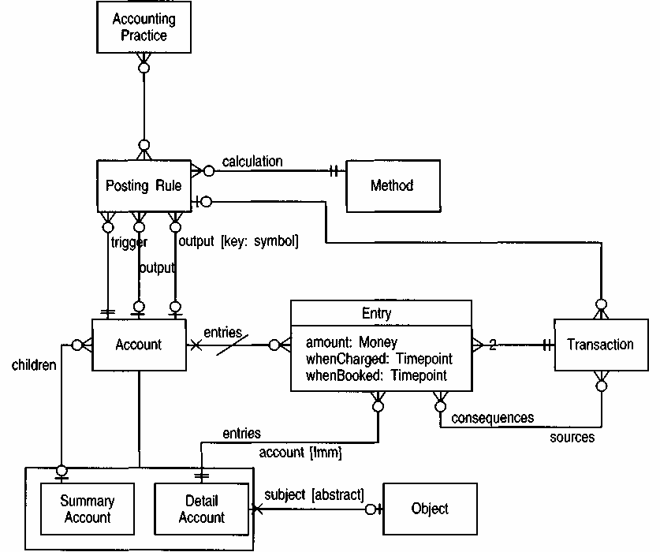

图 7.3 展示了电话服务的模型。客户可以拥有多条电话线路。电话服务实际上就是分配给客户的一条电话线路。每项电话服务都与一个会计准则相关联，该准则描述了其计费方式。此图说明了为什么在图 7.2 所示的明细账户中添加了主体映射。我们需要一种方法来确定明细账户所对应的服务，但我们不希望从账户包访问电话服务包，因为这会影响重用。因此，我们创建了明细账户的子类型。通过子类型化，可见性仅限于从子类型到超类型。服务账户完全可以知道电话服务，因为它们都属于电话服务包。但是，我们可能引用了一个明细账户，却不知道它是一个服务账户。明细账户上的抽象映射告诉我们，明细账户可以链接到一个对象（类型未指定）作为主体。所有这些都将通过明细账户的子类型来实现——这是多态性的一个经典案例。

Figure 7.3 shows the model of the phone service. Customers are allowed multiple phone lines. A phone service is really a phone line assigned to a customer. Each phone service is tied to an accounting practice that describes how it will be billed. This diagram illustrates why the subject mapping was added to detail account shown in Figure 7.2. We need a way to find out what detail account is accounting for, but we do not want visibility from the account package into the phone service package because it would compromise reuse. Thus we form a subtype of detail account. With subtyping, visibility only runs from the subtype to the supertype. It is perfectly permissible for the service account to know the phone service because they are both in the phone service package. However, we could have reference to a detail account and not know it is a service account. The abstract mapping on detail account tells us that a detail account could be linked to an object (type unspecified) as a subject. This will all be implemented by subtypes of detail account—a classic case of polymorphism.

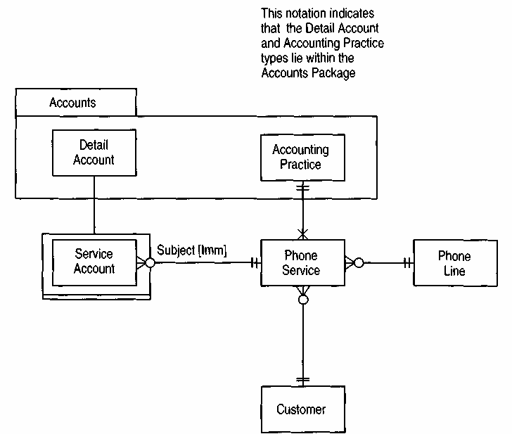

图 7.3 电话服务的结构模型。

Figure 7.3 The structural model of phone service.

#### 7.2 结构的实施

#### 7.2 Implementing the Structure

我们可以使用基于第 14 章所述模式的设计模板来实现这些模型。所有关联都通过访问和修改操作来表示。单值映射遵循 Smalltalk 的惯例。因此，过账规则上的名为 trigger 的映射由访问器 trigger 和修改器 trigger: anAccount 实现。多值映射（例如，会计实务的过账规则）具有访问器 postingRules 和修改器 addPostingRule: aPostingRule 和 removePostingRule: aPostingRule。

We can use design templates based on the patterns described in Chapter 14 to implement the models. All associations are represented by access and modify operations. Single-valued mappings follow the usual Smalltalk convention. Thus the mapping named trigger on the posting rule is implemented by the accessor trigger and modifier trigger: anAccount. Multivalued mappings—for example, posting rules on accounting practice— have accessor postingRules and modifiers addPostingRule: aPostingRule and removePostingRule: aPostingRule.

对帐户的条目操作是多态的——详细帐户返回一个实例变量，而汇总帐户对其子帐户求和（如清单 7.1 所示）。

The entries operation on account is polymorphic—detail account returns an instance variable while summary account sums over its children, (as shown in Listing 7.1).

```
Account»entries
^self subclassResponsibility
SummaryAccount>>entries I answer|
  answer  := SortedCollection sortBlock:[:a  :b|  a whenBooked > b whenBooked]. self
  detailAccounts inject:  answer into:
  [:total   :each  | total  addAll:
  each entries; yourself] . Aanswer
DetailAccount>>entries
  ^entries copy
```

清单 7.1 获取账户条目。

此模型没有账户类型。过账规则由汇总账户定义。本章示例中，我们可以使用账户类型或汇总账户来定义过账规则。使用汇总账户稍微复杂一些，因此更适合作为示例。已定义的高级汇总账户保存在账户类的一个类变量中，并可通过类方法 `findWithName: aString` 访问，其风格与 14.5.1 节相同。

This model has no account types. The posting rules are defined by summary accounts. For the examples in this chapter, we could use either account types or summary accounts to define posting rules. Using summary accounts is slightly more complicated, making it a better illustration. The high-level summary accounts that are defined are held in a class variable in the account class and are accessible with the class method findWithName: aString, following the style of Section 14.5.1.

代码的各个部分需要查找特定电话服务在特定汇总帐户下的服务帐户。不难想到几种方法：让电话服务查找给定汇总帐户下的帐户，或者让汇总帐户查找与其关联的电话服务的子帐户。这两种方法都合理，但很难选择哪种最佳。此外，每种方法都意味着特定的路径，其中一种可能比另一种更好。在这种情况下，我们可以使用完全不同的技术，按照 14.5.1 节所述构建一个类方法。然后，我们可以使用任一路径来实现该方法，并在不更改声明式接口的情况下修改该方法。如清单 7.2 所示，这也有助于记住这些查找方法的位置。

Various bits of code need to find a service account for a particular phone service under a particular summary account. It's not difficult to think up various ways of doing it: asking a phone service to find the account under a given summary account or asking a summary account to find its descendent attached to a phone service. Both of those ways are reasonable, but it is difficult to choose which one is the best. Furthermore, each implies a certain navigation path, and one may be better than the other. In such cases we can use an entirely different technique, building a class method following Section 14.5.1. Then we can implement the method with either path and change the method without changing the declarative interface. It also makes it easier to remember where these find methods are, as shown in Listing 7.2.

```
ServiceAccount class»findWithPhoneService: aPhoneService topParent: aTopSummaryAccount
  ^aPhoneService serviceAccounts detect: [:i| i parentTop = aTopSummaryAccount]
PhoneService»accountNamed: aString
  AServiceAccount
      findWithPhoneService: self
      topParent: (Account findWithName: aString)
```

列表 7.2 查找特定帐户。

在实际应用中，使用类似 accountNamed: aString 的电话服务方法通常更方便。该方法会调用 findWithPhoneService: topParent，从而兼具两种方法的优点。

In practice a method on phone service, such as accountNamed: aString, is often more convenient to use. That method calls findWithPhoneService: topParent and provides the advantages of both approaches.

这里的所有示例都使用两腿交易，尽管该模型支持多腿交易。我们可以使用清单 7.3 中所示的特殊交易创建方法来创建两腿交易。一种方法包含所有信息，包括源条目和创建过账规则。另一种方法用于在开始时读取初始属性。

All the examples here use two-legged transactions, although the model supports multilegged transactions. We can create a two-legged transaction with the special creation methods for transaction shown in Listing 7.3. One method carries all the information, including the source entries and the creation posting rule. The other method is used for the initial attributes read in at the beginning.

清单展示了多种编码技巧。构造函数参数方法 [l]（以 set 为前缀）使用参数初始化新对象。在创建参数方法中，使用 `requi re:` 消息进行前提条件检查。为了提高性能，可以通过重新定义 `requi re:` 方法来移除此检查。另一个体现契约式设计 [3] 的元素是使用不变式检查。

The listing shows a number of coding techniques. A constructor parameter method [l] (prefixed with set) initializes the new object with parameters. Within the creation parameter method, precondition checking is done with the requi re: message. To improve performance, the checking can be removed by redefining the requi re: method. Another element from design by contract [3] is the use of an invariant check.

#### 7.3 设置新的电话服务

#### 7.3 Setting Up New Phone Services

创建新的电话服务并非仅仅是实例化一个电话服务对象。还需要创建服务帐户才能启动会计系统。虽然本示例仅包含一个会计准则，但它应该足够灵活，可以根据所使用的会计准则设置帐户，如图 7.4 和 7.5 以及清单 7.4 所示。

Creating a new phone service is not simply a question of instantiating a phone service object. Service accounts must also be created to get the accounting system going. Although this example does not contain more than one accounting practice, it should be flexible enough to set up the accounts for whichever accounting practice is being used, as shown in Figures 7.4 and 7.5, and Listing 7.4.

```
Transaction class»newWithAmount: aQuantity from: fromAccount to: toAccount
whenCharged: aTimepointOrDate
  ^self
    newWithAmount:  aQuantity
    from:  fromAccount to:
    toAccount
    whenCharged:  aTimepointOrDate
    creator:  nil sources:  Set new
newWithAmount: aQuantity from:  fromAccount to:  toAccount whenCharged:
aTimepointOrDate creator: aPostingRule sources: aSetOfEntries ^self new
    setAmount:  aQuantity
    from:  fromAccount to:
    toAccount
    whenCharged:  aTimepointOrDate
    creator:  aPostingRule sources:
    aSetOfEntries
Transact ion»setAmount:  aMoney from:  aDebitAccount    to: aCreditAccount    whenCharged:
aTimepointOrDate creator: aPostingRule sources: aSetOfEntries "private" self require:
        [aMoney isKindOf:  Money. aDebitAccount
        isKindOf:  ServiceAccount. aCreditAccount
        isKindOf:  ServiceAccount.
    (aTimepointOrDate isKindOf:  Date) or:   [aTimepointOrDate isKindOf:  Timepoint]. (creator ==
    nil) or:   [creator isKindOf:  PostingRule]] . self initialize, self addEntry:   (Entry new
    setAccount:  aCreditAccount
    amount:  aMoney charged:
    aTimepointOrDate). self addEntry:
    (Entry new setAccount:
    aDebitAccount amount:  aMoney
    negated charged:
    aTimepointOrDate). creator:=
    aPostingRule.
aSetOfEntries do:   [:i|  self sourcesAdd:  i]. self
checklnvariant. Object»require:  aBooleanBlock
aBooleanBlock value ifFalse:   [self error:   'Precondition Violati on']
Transaction»checklnvariant |balance| balance  := entries
    inject:  Quantity zero
    into:   [:total   :each  |  total   := total  + each
  amount], self require:   [balance = Quantity zero].
```

清单 7.3 创建双边交易。

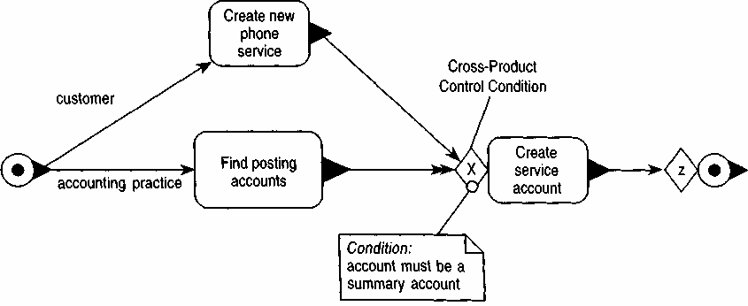

图 7.4 创建新电话服务的事件图。

Figure 7.4 Event diagram for creating a new phone service.

此图使用跨产品控制条件（常规事件图的扩展）。该控制条件针对其 传入触发器的每种组合进行评估，在本例中，即针对新建电话服务和记账科目的每种组合。它会为 会计实务中的每个电话服务和汇总记账科目调用创建服务科目操作。

This diagram uses a cross-product control condition (an extension to the regular event diagrams). The control condition is evaluated for each combination of its incoming triggers, in this case for each combination of new phone service and posting account. It invokes the create service account operation for each phone service and summary posting account in the accounting practice.

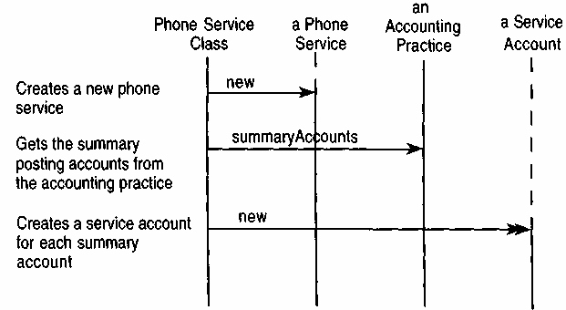

图7.5创建新电话服务的交互图。

Figure 7.5 Interaction diagram for creating a new phone service.

为了确定需要哪些账户，需要向会计事务所索取其过账账户，如图 7.6 和清单 7.5 所示。会计事务所可以包含引用明细账户的过账规则（尽管此处并未这样做）。因此，必须对过账账户进行筛选，仅保留汇总账户。

To determine which accounts are required, the accounting practice is asked for its posting accounts, as shown in Figure 7.6 and Listing 7.5. An accounting practice can contain posting rules that reference detail accounts (although that it is not done here). Thus the posting accounts have to be filtered to keep only the summary accounts.

```
PhoneService class»newWithAccountingPractice:  anAccountingPractice customer:
aCustomer phoneLine: aPhoneLine
  Aself new
    setAccounti ngPracti ce: anAccounti ngPracti ce customer:
    aCustomer phoneLine: aPhoneLine
PhoneService»setAccountingPractice: anAccountingPractice customer: aCustomer phoneLine:
aString
  InewObj summaryAccounts| self
  require:
    [(anAccountingPractice isKindOf: AccountingPractice) &
    (aCustomer isKindOf: Customer)].
  name := (aCustomer name), '#', (aCustomer phoneServices size + 1) printString.
  accountingPractice := anAccountingPractice. self setCustomer: aCustomer. line := aString.
  self createServiceAccounts. Aself
PhoneService»createServiceAccounts "private -
  initializing" (self accountingPractice
  summaryAccounts) do:
    [:each | ServiceAccount newWithPhoneService: self parent: each].
```

清单 7.4 设置新的电话线。

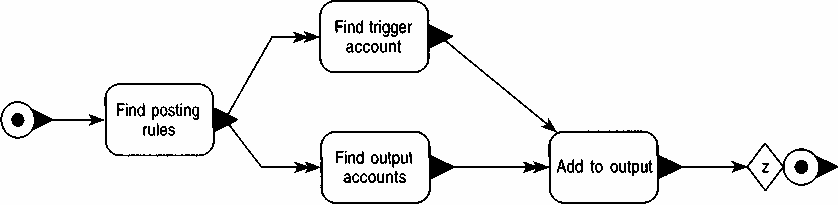

图 7.6 查找发帖帐户。

Figure 7.6 Finding posting accounts.

我们需要每个过账规则的触发账户和所有输出账户 。

We want the trigger account for each posting rule and all the output accounts for each posting rule.

```
Accounti ngPractice»summaryAccounts
    ^self postingAccounts select: [:each | each .isSummary] Accounti
ngPractice»postingAccounts
  |answer|
  answer := Set new.
  postingRules do:
    [:each |
    answer add: each trigger.
    answer addAll: each outputs].
  Aanswer
```

清单 7.5 会计事务所可以提供其汇总账目。

#### 7.4 设置通话

#### 7.4 Setting Up Calls

电话通话被建模为从网络账户到基本时间账户的交易。电话通话记录的单位是分钟。

Phone calls are modeled as transactions from a network account to a basic time account. The units for phone call entries are minutes.

以下方法展示了如何设置电话服务并进行一些示例呼叫。请注意，它定义在一个名为 Scene 的类中，如清单 7.6 所示。测试方法可能会变得非常复杂；因此，最好将它们放在一个场景对象中（在测试用例中使用 scene）。

The following method shows the setting up of a phone service and the placement of some sample calls. Note that it is denned on a class called Scenariol, as shown in Listing 7.6. Test methods can get quite complex; thus it is good practice to put them on a scenario object (using scenario in the

```
Scenariol»setupCa11s
  |adams network | self
  init.
  adams := Customer new name: 'Adams'; persist.
  theService := PhoneService
    newWithAccounti ngPracti ce: (AccountingPractice basicBi11ingPlan) customer:
    adams
    phoneLine: (PhoneLine new name: '617 123 1234'). network := theService accountNamed:
  'Network'. basicAccount := ServiceAccount findWithPhoneService: theService
  topParent:
                      (Account findWithName: 'Basic Time').
Transaction
  newWithAmount: (Quantity n:'10 min') from:
  network to: basicAccount whenCharged:
  (Timepoint date: 'jan 1 1995' time:
  '13:15'). Transaction
  newWithAmount: (Quantity n:'8 min') from:
  network to: basicAccount whenCharged:
  (Timepoint date: 'jan 1 1995' time:
  '14:25'). Transaction
  newWithAmount: (Quantity n:'6 min1) from:
  network to: basicAccount whenCharged:
  (Timepoint date: 'jan 1 1995' time:
  '19:05'). Transaction
  newWithAmount: (Quantity n:'33 min') from:
  network to: basicAccount whenCharged:
  (Timepoint date: 'jan 1 1995' time: '20:20').
  ^basicAccount
```

清单 7.6 设置测试电话。

（此处“用例”一词并非如第 9.4 节所定义）在没有合适的测试框架的情况下，为了控制这些用例，需要使用它们。变量 basicAccount 和 theService 是此测试类的类变量。

sense of a use-case, not as defined in Section 9.4) to keep them under control if no proper testing framework is available. The variables basicAccount and theService are class variables of this test class.

使用用户自定义的基础类（例如 quantity）可能会使创建新对象变得困难。因此，quantity 类有一个方法 n: aString，它可以根据字符串创建一个新的 quantity 对象。这是我个人使用的约定，因为 fromString: aString 可能会变得相当笨拙。

Using user-defined fundamental classes, such as quantity, can make creating new objects difficult. Hence quantity has a method n: aString, which creates a new quantity from the string. This is a personal convention that I use since fromString: aString can get rather unwieldy.

#### 7.5 实施基于账户的解雇

#### 7.5 Implementing Account-based Firing

这里我们使用基于账户的触发方案（参见第 6.7.3 节）。每个账户都有一个方法来处理自身，该方法会触发所有以该账户为触发器的过账规则，如清单 7.7 所示。

We use the account-based triggering scheme here (see Section 6.7.3). Each account has a method to process itself by firing all posting rules that use it as a trigger, as shown in Listing 7.7.

[output not shown]

列表 7.7 一个帐户触发出站发布规则。

条目存储在有序集合中，新条目会添加到集合末尾。TastProcessed 实例变量用于跟踪处理状态。

Entries are held in orderedCollection, with new ones added on the end. The TastProcessed instance variable keeps track of the state of processing.

#### 7.6 将通话分为白天和晚上

#### 7.6 Separating Calls into Day and Evening

为了将通话分为白天通话和晚上通话，我们查看每笔记录，考虑记录的时间，然后从基本时间账户向白天账户或晚上时间账户进行交易。

To separate the calls into day and evening calls, we look at each entry, consider the time on the entry, and then make a transaction from the basic time account into either the day time account or the evening time account.

逐条处理条目的过账规则非常常见。我们可以创建一个名为“逐条过账规则”（EachEntryPR 类）的抽象子类型过账规则。如图 7.7 和清单 7.8 所示，该子类型会调用处理程序 `Entry: anEntry`，处理触发账户中每个未处理的条目。消息 `currentInput:` 会加载一个实例变量来保存过账规则正在处理的服务账户，如清单 7.9 所示。该变量仅可通过私有方法访问，并且仅在 `processAccount` 执行期间定义。临时的私有实例变量通常用于处理临时数据。

A posting rule that operates on an entry-by-entry basis is quite common. We can create an abstract subtype of posting rule called an each-entry posting rule (the class EachEntryPR). This subtype calls the operation process Entry: anEntry on each unprocessed entry in the triggering account, as shown in Figure 7.7 and Listing 7.8. The message currentInput: loads an instance variable to hold the service account that is being processed by the posting rule, as shown in Listing 7.9. It is accessed by private methods and is only defined within the execution of processAccount. A temporary, private instance variable is often

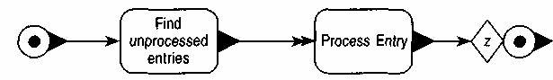

图 7.7 每个条目过账规则处理帐户的方法。

Figure 7.7 Each-entry posting rule's method for processing an account.

我们对每个未处理的条目使用处理条目操作。

We use the process entry operation on each unprocessed entry.

[output not shown]

列表 7.8 EachEntryPR 如何处理触发帐户。

```
PostingRule>>currentInput:  anAccount
    "private"
self require: [currentlnput isNil].
currentlnput := anAccount. self
setCurrentOutputs
PostingRule»setCurrentOutputs "private"
    currentOutputs := Dictionary new.
    outputs associationsDo: [: each |
    currentOutputs at: each key put:(Servi
    ceAccount
findWithPhoneService: (currentlnput phoneService) topParent: each value)]
PostingRule»clean "private"
    currentlnput := nil.
    currentOutputs := nil.
```

清单 7.9 设置电流输入和输出。

在这种情况下使用这种方法是因为发布规则通常（尽管本例并非如此）被定义为实例。因此，我们无法实例化它们来调用规则。另一种方法是将已定义的发布规则实例视为原型[2]，并克隆它以执行。

used in such cases because posting rules in general (although not in this case) are defined as instances. Thus we cannot instantiate them for invocation of the rule. An alternative is to treat the defined posting rule instance as a prototype [2] and clone it for execution.

currentInput: 消息还会为与输入电话服务相同的电话服务设置当前输出服务帐户。

The currentInput: message also sets up current output service accounts for the same phone service as the one provided as input.

此方法并不执行实际的计算和过账操作。这些操作由 `processEntry:` 方法完成，该方法是抽象的，应该由子类定义。因此，这里存在三层子类化。`PostingRule` 定义了过账规则的基本接口和服务。`EachEntryPR` 类中的 `process account` 方法是一个模板方法，它概述了逐条处理账户条目的步骤，但将具体如何处理每条条目的任务留给了子类。

This method does not do the actual calculation and posting. Instead it is done by processEntry:, which is abstract and should be defined by subclasses. Thus we see three layers of subclassing here. PostingRule defines the basic interface and services of posting rules. The process account method on EachEntryPR is a template method,2 which outlines the steps of processing an account entry by entry but leaves a subclass to actually work out how to process each entry.

对于此发布规则，我们可以定义一个名为 EveningDaySplitPR 的 EachEntryPR 子类。这是一个单例类实现的示例（参见 6.6.1 节）。该类中硬编码了相应的账户，这些账户在初始化时设置，如清单 7.10 所示。

For this posting rule we can define new subclass of EachEntryPR called EveningDaySplitPR. This is an example of the singleton class implementation (see Section 6.6.1). Hard-coded into this class are the appropriate accounts, which are set up at initialization, as shown in Listing 7.10.

```
EveningDaySplitPR»initialize
  super initialize.
  outputs := Dictionary new .
  outputs
    at: #evening
    put: (Account findWithName: 'Evening Time'), outputs
    at: #day
    put:   (Account findWithName:   'Day Time')
```

清单 7.10 初始化晚间/白天拆分流程规则。

分割是通过重写的 processEntry: 方法完成的，如图 7.8 和清单 7.11 所示。

The splitting is done by the overriding processEntry: method, as shown in Figure 7.8 and Listing 7.11.

#### 7.7 时间充电

#### 7.7 Charging for Time

如图 7.9 所示，白天和晚上的通话计费模式相同。费用同样是逐笔计算的，因此使用了 EachEntryPR 的子类。使用了两条过账规则——一条用于白天，一条用于晚上。这两条规则都使用同一个类 TransformPR。

Charging for both the evening and day calls follows the same pattern, as shown in Figure 7.9. Again the charges are calculated on an entry-by-entry basis, so a subclass of EachEntryPR is used. Two posting rules are used—one for day, one for evening. The same class, TransformPR, is used for both of them.

模板方法是算法的骨架，它将一些步骤推迟到子类中[2]。

A template method is a skeleton of an algorithm that defers some steps to subclasses [2].

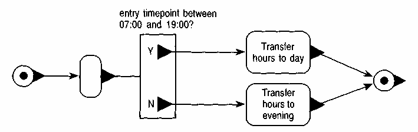

图 7.8 晚间/白天拆分流程规则的流程输入操作方法。

Figure 7.8 Evening/day split process rule's method for the process entry operation.

```
EveningDaySplitPR>>processEntry:  anEntry
  Transaction
      newWithAmount:   (anEntry amount)
      from:   (anEntry account) to:
      (self outputFor:  anEntry)
      whenCharged:   (anEntry timepoint)
      creator:  self
  sources:   (Set with:  anEntry) EveningDaySpl i tPR>>outputFor:
anEntry A(anEntry timepoint time > (Time fromString:   '19:00'))
| (anEntry timepoint time < (Time fromString:   '07:00')) ifTrue:
[self currentOutputs at:  #evening ] ifFalse:   [self
currentOutputs at:  #day].
```

清单 7.11 晚间/白天拆分处理规则如何处理条目。

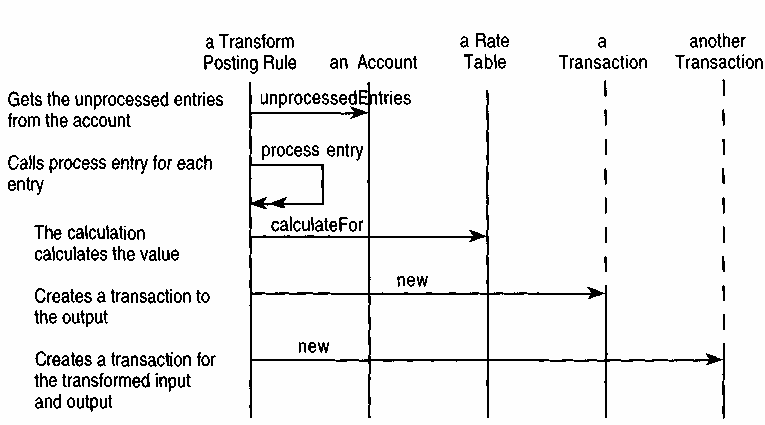

图 7.9 具有转换过账规则的帐户处理交互图。

Figure 7.9 Interaction diagram for processing an account with a transform posting rule.

此记账规则的一个特殊之处在于，它由分钟数触发，但生成的条目却以美元计价，因此被称为“转换”。其实际操作是生成两笔交易。第一笔交易将分钟数转回网络账户，从而完成分钟数的循环。第二笔交易在货币领域生成一笔新交易：从网络收入账户转至活动账户，如图 7.10 和清单 7.12 所示。

A special feature of this posting rule is that it is triggered by an entry in minutes but produces entries in dollars, hence the term transform. Its actual reaction is to generate two transactions. One transfers the minutes back to the network account, thus completing the cycle for minutes. The second generates a new transaction in the money world: from a network income account to an activity account, as shown in Figure 7.10 and Listing 7.12.

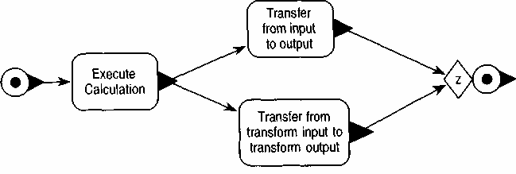

图 7.10 流程 输入操作转换过账规则方法的事件图。

Figure 7.10 Event diagram for transform posting rule's method for the process entry operation.

```
TransformPR»processEntry: anEntry
    Transaction
      newWithAmount:   (anEntry amount)
      creator:  self
      from:   (anEntry account)
      timepoint:   (anEntry timepoint)
      to:   (self currentOutputs at:   #out)
      sources:   (Set with:  anEntry). Transaction newWithAmount:
    (self transformedAmount:  anEntry)
      creator:  self

timepoint: (anEntry timepoint) to: (self currentOutputs
at: #transformedTo) sources: (Set with: anEntry).
TransformPR»transformedAmount: anEntry
    "private"
    ^self calculationMethod calculateFor: anEntry amount
```

列表 7.12 转换发布规则如何处理条目。

转换后的金额由方法对象（参见 6.6.2 节）计算得出，具体来说，是由费率表（例如表 7.1 和表 7.2 中所示的费率表）计算得出。该方法类定义了抽象的 calculateFor: 方法。费率表是一个子类，它存储一个包含两列的数量表，用于生成问题所需的分级收费。它使用字典实现。字典的键指示各个阈值点，并且

The transformedAmount is calculated by a method object (see Section 6.6.2), specifically a rate table, such as that shown in Tables 7.1 and 7.2. The method class defines the abstract calculateFor: method. The rate table is a subclass that stores a two-column table of quantities to produce the kind of graded charging that the problem demands. It is implemented using a dictionary. The keys of the dictionary indicate the various threshold points, and

表 7.1 日间通话费率。

| 通话时长 | 成本 |
| --- | --- |
| 最多 1 分钟 | 98美分 |
| 1分钟以上 | 30美分 |

| 通话时长 | 成本 |
| --- | --- |
| 最多 1 分钟 | 70美分 |
| 1-20分钟 | 20美分 |

对应的数值表示在该阈值范围内适用的费率。列表 7.13 展示了晚间费率的设置方式。最高费率表示超过最高阈值后适用的费率。

the corresponding value indicates the rate that applies up to that threshold. Listing 7.13 shows how the evening rate is set up. The top rate indicates which rate applies once you get over the top threshold.

```
RateTable>>eveningRateTable
    I  answer  |
    answer := RateTable new.
    answer
        rateAt: (Quantity n: '1 min') put:
        (Quantity n: '.7 USD').
    answer
        rateAt: (Quantity n: '21 min') put:
        (Quantity n: '.2 USD').
    answer topRate: (Quantity n: '.12 USD'). ^answer
```

清单 7.13 在价格表对象中设置晚间价格。

清单 7.14 展示了费率表如何计算金额。它分两步进行：首先，遍历费率表中的每一步；其次，加上超过最高阈值的任何金额。这里无需绘制图表；表格本身已经从概念上清晰地说明了所需的操作。需要特别注意的是，这些系统可以通过使用绝对值来平等地处理正数和负数。

Listing 7.14 shows how the rate table then calculates the amount. It does this in two parts: taking each step in the rate table and adding any amount over the top threshold. There is not much point showing a diagram for this; the tables indicate what is needed from a conceptual perspective clearly enough. One particular thing to watch for with these systems is that they can handle both positive and negative numbers the same by using absolute values.

#### 7.8 计算税款

#### 7.8 Calculating the Tax

最终的记账规则显示了税款的计算方法。该规则与之前的规则不同，它并非逐笔计算，而是需要查看一个月内的所有费用以评估税款。

The final posting rule shows the calculation of the tax. This rule differs from the previous rules in that it does not operate on an entry-by-entry basis. This posting rule has to look at all charges over a one-month period to assess the tax.

另一个复杂之处在于，我们无法（或者更确切地说，我们不希望）保证记账规则仅在月底运行一次。因此，记账应考虑因之前已收取的税款。这符合记账规则应遵循的原则。

Another complication is that we cannot (or rather do not wish to) guaran-tee that the posting rule is only run once at the end of the month. Thus the posting should take into account any tax already charged for the month due to an earlier firing. This follows the principle that the posting rules should be

[output not shown]

清单 7.14 费率表如何计算输入量的值。

这些定义独立于它们的触发方式。这提高了模型的灵活性并降低了模型的耦合性。

defined independently of how they are fired. This increases flexibility and reduces coupling in the model.

MonthlyChargePR 类是过账规则的子类型，因此实现了 processAccount，如图 7.11 和清单 7.15 所示。

The MonthlyChargePR class is a subtype of posting rule and thus implements processAccount, as shown in Figure 7.11 and Listing 7.15.

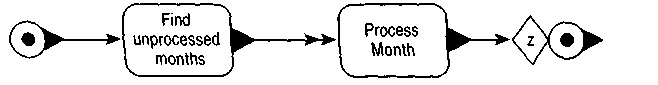

图 7.11 月度费用记账规则处理帐户的方法。

Figure 7.11 Monthly charge posting rule's method for processing an account.

该过程基于一段时间内的余额，而不是每笔交易。

This process is based on a balance over a time period, rather than each entry.

每个月都使用 processForMonth: 进行处理，如图 7.12 和清单 7.16 所示。

Each month is processed with processForMonth:, as shown in Figure 7.12 and Listing 7.16.

最后一笔交易是从输出账户到输入账户，因为由于纳税义务，活动账户会增加。

The final transaction is from the output account to the input account, because the activity account will be increased due to the tax liability.

[output not shown]

清单 7.15 月度费用记账规则如何处理帐户。

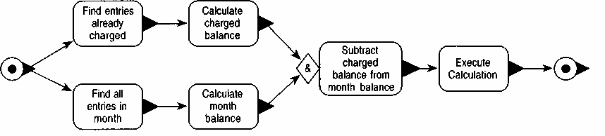

图 7.12 一个月的处理事件图。

Figure 7.12 Event diagram for processing a month.

[output not shown]

清单 7.16 月度费用记账规则如何处理一个月。

#### 7.9 总结性思考

#### 7.9 Concluding Thoughts

这是一个非常简单的例子，因此很难从中得出太多结论。读者完全可以论证，这个问题可以用更简单的方式解决，而无需所有这些框架。然而，该框架对于可扩展性至关重要。一个实际的企业可能拥有数十个业务单元，每个业务单元又有数十条流程规则。利用这种结构，我们可以表示会计业务单元的新计费方案。当我们构建一个新的业务单元时，我们会创建一个新的过账规则实例网络。我们可以在系统仍在运行的情况下完成此操作，而无需重新编译或重建系统。虽然偶尔会遇到需要新的过账规则子类型的情况，但这种情况非常罕见。

This is a very simple example, so it is difficult to draw too many conclusions from it. The reader can convincingly argue that this problem can be tackled in a much simpler form without all this framework stuff. The framework, however, is valuable for scalability. A real business may have dozens of practices, each with dozens of process rules. With this structure we represent a new billing plan by an accounting practice. When we build a new practice, we create a network of new instances of the posting rule. We can do this without any recompilation or rebuilding of the system, while it is still up and running. There will be unavoidable occasions when we need a new subtype of posting rule, but these will be rare.

##### 7.9.1 发布规则的结构

图 7.13 展示了本章讨论的过账规则的泛化结构。抽象过账规则类包含一个抽象方法 processAccount。各个子类型都实现了 processAccount 方法。每个条目过账规则通过调用另一个抽象方法 processEntry 来实现该方法。其他子类型根据需要实现 processEntry 方法。日/夜拆分过账规则的 processEntry 方法被硬编码，而转换过账规则则委托给费率表。示例展示了如何……

Figure 7.13 shows the generalization structure of the posting rules discussed in this chapter. The abstract posting rule class has an abstract processAccount method. The subtypes each implement processAccount. The each entry posting rule implements this method by calling another abstract method, processEntry, on each entry. The further subtypes implement processEntry as needed. The day/evening split posting rule's method is hard coded, while the transform posting rule delegates to a rate table. The example shows how a

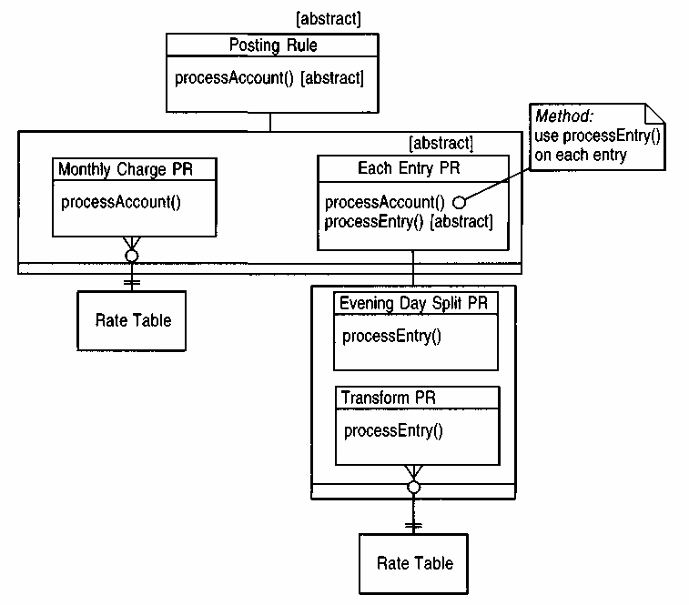

图 7.13 发布规则的概括结构

Figure 7.13 Generalization structure of posting rules

抽象方法、多态性和委托的结合可以提供一种结构，以有组织的结构支持各种发布规则。

combination of abstract methods, polymorphism, and delegation can provide the kind of structure that supports a variety of posting rules in an organized structure.

这并非我们唯一可以使用的记账规则结构。另一种方法是将计算费用的两个步骤合并为一个步骤。这样的记账规则将包含两个费率表，一个用于日间费用，一个用于夜间费用，并负责费用拆分和费率表计费。

This is not the only structure of posting rules we could use. Another alternative would be to combine the two steps of working out the charge into a single step. Such a posting rule would have two rate tables, one for day charges and one for evening charges, and would be responsible for both the splitting and the rate table charging.

划分发布规则并没有固定的规则。我们的根本目标是在无需创建新的发布规则子类型的情况下构建新的实践。我们希望发布规则子类型的数量尽可能少，这样便于理解和维护。但同时，这些子类型也必须具备所有必要的功能，以便我们能够将它们组合起来用于新的实践。我们希望尽可能减少创建新发布规则子类型的次数。

There are no rules for deciding how to divide up posting rules. Our fundamental aim is to be able to build new practices without needing a new subtype of posting rule. We want to have as small a set of subtypes of posting rule as we can, for that will make it easier to understand and maintain the posting rule types. Yet we need these subtypes to have all the function that is required so we can put them together for new practices. We want to minimize the times when we need to build new posting rule subtypes.

更简单的发布规则适用于规模更大的实践，通常也更容易被广泛应用。我倾向于先将发布规则限制在较小的行为范围内。如果我发现某种发布规则组合经常被使用，那么我可能会构建一个功能更强大的发布规则来表示这种组合。

Simpler posting rules result in larger practices and are usually more widely available. I tend to keep posting rules to small behaviors initially. If I see a frequently used combination of posting rules, then I might build a more functional posting rule to represent that combination.

##### 7.9.2 何时不应使用该框架

另一种替代此框架的方法是，每个计费方案仅使用一个类来处理所有行为（日/晚拆分、计费和税费），如图 7.14 所示。该类将接收一个月内的所有条目并生成账单。每个计费方案都将有一个这样的对象。

An alternative to using this framework is to have only one class per billing plan to handle all the behavior (day/evening split, charging, and taxing), as shown in Figure 7.14. The class would take all the entries in a month and produce a bill. There would be one such object for each billing plan.

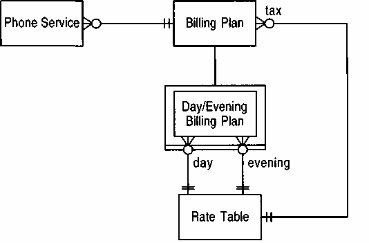

图 7.14 使用计费方案。

Figure 7.14 Using a billing plan.

计费方案虽然简单，但灵活性稍差。

A billing plan is simple but not as flexible.

这种方法相当可行。虽然计费方案可能有很多种，但通常有一些基本的计费方法可以进行参数化，就像转换过账规则可以针对许多不同的费率表进行参数化一样。就这个问题而言，这种类型的计费方案可以通过晚间费率表、日间费率表和税收费率表进行参数化。

This approach is quite plausible. Although there may be many billing plans, there are usually a few basic methods for billing that can be parameterized, much as the transform posting rule can be parameterized for many different rate schedules. Such a type, for this problem, would be parameterized by an evening rate table, a day rate table, and a taxing rate table.

关键问题在于计费方案有多少种子类型。如果我们可以用十几种计费子类型来表示所有的计费结构，

The key question is how many subtypes of billing plan there are. If we can represent all the billing structures with a dozen or so subtypes of billing

如果有一个计划（尽管可能有数百个实例），那么使用计费计划类型是合理的。会计模型的优势在于它允许您……

plan (although there might be hundreds of instances), then using a billing plan type is plausible. The accounting model's strength is that it allows you

通过将过账规则和帐户对象连接起来，构建等效于新型计费计划子类型的功能。如果计费计划子类型众多或经常变化，这将具有强大的优势。

to build the equivalent of new subtypes of billing plan by wiring together posting rule and account objects. This is a powerful advantage if there is a large or frequently changing set of subtypes of billing plan.

另一种理解方式是将计费计划视为一条过账规则，它将基本时间账户中的数据一步过账到活动账户。使用账户仍然很有价值，因为它可以提供计费计划输入和结果的通话和费用历史记录。但我们会丢失中间总计。

Another way to think about it is to consider the billing plan as a posting rule that posts from the basic time account to the activity account in one step. Using accounts would still be valuable to give the history of phone calls and charges at the input and result of billing plan. We would lose the intermediate totals.

##### 7.9.3 会计实务图表

图表通常有助于将复杂问题可视化。图 7.15 和 7.16 是这方面的一些建议（当然也只是初步的）。这类图表有助于处理复杂的操作。我们可以设想，通过绘制图表来构建系统，从而减少所需的编程量，进而提高此类应用程序的效率。

A diagram often helps to visualize a complex problem. Figures 7.15 and 7.16 are suggestions (and most certainly tentative ones) in that direction. Complex practices will be helped by these kinds of diagrams. We might imagine that we could build a system by drawing a diagram and decreasing the amount of programming required and thus increase the productivity of such applications.

练习应该能形成一个简洁但又能传达关键信息的图表。图 7.15 的优点在于其简洁性，展示了关键的触发和输出关系。然而，它并没有像图 7.16 那样完整地展示所有已核算项目的流程。如果您使用这些图表，请注意以下事项：

Practice should result in a diagram form that is simple yet conveys the key information. Figure 7.15 has the advantage of being simple, displaying the key triggering and output relationships. It does not, however, show the full flow of accounted items in the way that Figure 7.16 does. If you use these

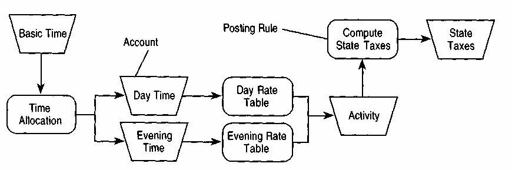

图 7.15 流程规则和帐户布局的简单图示方法。

Figure 7.15 A simple way of diagramming the layout of process rules and accounts.

它显示了每个过账规则的触发条件和主要输出账户，但隐藏了完整的 交易流程。

It shows the trigger and main output account for each posting rule but hides the full flow of transactions.

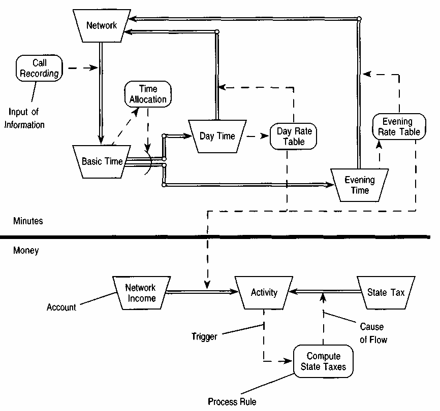

图 7.16 账户和记账规则的更直观的图示。

Figure 7.16 A more expressive diagram of the accounts and posting rules.

此图清晰地展示了交易流程。每条记账规则都由一个 账户触发，并引发一系列交易流。流程方向显示了 款项的提取和存入位置。该图包含更多信息，因此也 更为复杂。

This diagram makes the flow of transactions explicit. Each posting rule is triggered by a single account and causes a number of flows. The direction of the flow shows where items are withdrawn and deposited. The diagram shows more information and is thus more complicated.

对于模式，我强烈建议使用图表。可以先从这里建议的图表开始，然后让图表标准逐渐演变成最实用的一种（并告诉我它是什么）。

patterns, I strongly recommend using diagrams. Start with the ones suggested here and let the diagram standard evolve to one that is the most useful (and let me know what it is).

#### 参考

#### References

1. Beck, K. Smalltalk 最佳实践模式。第 1 卷：编码。Englewood Cliffs, NJ: Prentice Hall，即将出版。
2. Beck, K. Smalltalk Best Practice Patterns. Volume 1: Coding. Englewood Cliffs, NJ: Prentice Hall, in press.
3. Gamma, E.、R. Helm、R. Johnson 和 J. Vlissides。《设计模式：可重用面向对象软件的要素》。马萨诸塞州雷丁：Addison-Wesley，1995 年。
4. Gamma, E., R. Helm, R. Johnson, and J. Vlissides. Design Patterns: Elements of Reusable Object-Oriented Software. Reading, MA: Addison-Wesley, 1995.
5. Meyer, B.” 应用“合同设计”“IEEE计算机”，25,10 (1992)，第40-51页。
6. Meyer, B." Applying 'Designby Contract,"'IEEE Computer, 25,10 (1992), pp. 40-51.

### 第八章 计划

### Chapter 8. Planning

计划是任何大型项目的重要组成部分。许多管理者花费大量时间制定和跟踪计划。本章提供了一些基本的计划模式。这些模式既包括具体的计划，也包括可以重复使用的标准流程——即既定的规程，也包括规范的程序。

Planning is a vital part of any large endeavor. Many managers spend most of their time developing and tracking plans. This chapter provides some basic patterns for planning. The patterns describe individual plans as well as protocols—standard procedures that can be used repeatedly.

在某个领域内执行的任何操作都可以被记录。拟议操作和已执行操作（8.1）模式将操作的可能状态分为两个关键子类型，分别代表意图和实际发生的情况。类似地，操作的结束状态也被分为已完成操作和已放弃操作（8.2）。已放弃操作表示操作的最终取消，而暂时中止操作则用暂停（8.3）表示。

Any action carried out within a domain can be recorded. The proposed and implemented action (8.1) pattern divides the possible states of an action into two key subtypes, which represent the intention and what actually happens. The end of an action is similarly divided into completed and abandoned actions (8.2). An abandoned action represents a final cancellation of the action, and temporary holds on an action are represented by suspension (8.3).

计划（8.4）用于容纳一组拟定的行动。我们讨论计划的结构，这些结构记录了一组行动的依赖关系和顺序，同时允许单个行动出现在多个计划中。后一个特性对于协调多个计划至关重要，因为这些计划都是一次性的安排。协议（8.5）用于多次重复的标准计划。

A plan (8.4) is used to hold a group of proposed actions. We discuss structures of plans that record the dependency and sequencing of a group of actions while allowing a single action to appear in several plans. The latter property is essential to choreographing multiple plans, which are one -off arrangements. A protocol (8.5) is used for standard plans that are repeated many times.

执行一项行动需要资源。资源分配模式（8.6）描述了拟议行动和已执行行动的协议。我们考虑两种不同类型的资源：消耗品（由行动使用）和资产（随时间推移而使用）。

Carrying out an action requires resources. The resource allocation (8.6) pattern describes protocols for proposed and implemented actions. We consider two different kinds of resources: consumables, which are used by actions, and assets, which are used over time.

到目前为止，我们对计划的讨论主要集中在行动的规划和监控上，而忽略了行动的影响。我们讨论的最后一个模式处理结果函数和启动函数（8.7），它将本章中的模式与第三章中开发的观察和测量模式联系起来。这些函数使我们能够说明我们认为一项行动已经实现了什么（结果），一项方案应该实现什么（结果函数），以及什么条件促使我们启动一项方案（启动函数）。

So far our discussion of plans has focused on planning and monitoring actions and has ignored the effects of the actions. The final pattern we discuss handles outcome and start functions (8.7), which tie the patterns in this chapter with the observation and measurement patterns developed in Chapter 3. These functions allow us to say what we think an action has achieved (outcome), what a protocol should achieve (outcome function), and what conditions make us want to begin a protocol (start function).

规划是一个复杂的领域，本章中的模式，甚至比其他章节更甚，并非旨在涵盖所有情况。这些模式源自 Cosmos 临床流程模型 [1]，因此其构建方式明显倾向于支持医疗保健规划。资源方面的信息则来自与 Cosmos 的开发者和用户的未公开讨论，以及 NHS 通用基本规范 [2] 的影响。

Planning is a complex area, and the patterns in this chapter, even more than other chapters, are not intended to be complete. The patterns came out of the Cosmos Clinical Process Model [1], and its constructions are thus decidedly bent in directions that support health care planning. The resource side comes from unpublished discussions with the developers and users of Cosmos, and the influence of the NHS Common Basic Specification [2].

关键概念：拟议行动、已实施行动、计划、暂停、资源分配、资产、消耗品、临时资源、启动功能、结果功能

Key Concepts Proposed Action, Implemented Action, Plan, Suspension, Resource Allocation, Asset, Consumable, Temporal Resource, Start Function, Outcome Function

#### 8.1 拟议和已实施的行动

#### 8.1 Proposed and Implemented Action

任何计划的基础都在于人们采取的基本行动。要详细描述行动的构成要素，往往只能给出一个大致的概括。计划可以是粗略的，由大型行动组成；也可以是精细的，由小型行动组成。行动可以具有一系列属性，例如参与者、时间以及地点。鉴于这些粗略的属性，我们很难提供更详细的描述，只能提供参与者、时间参考和地点这几个最通用的术语，如图 8.1 所示。

The basis of any plan consists of the fundamental actions that people take. It is difficult to give any more than an outline description of what makes up an action. A plan can be coarse, consisting of large actions, or it can be finegrained, consisting of small actions. Actions can have a range of properties, based on who, when, and where. With such coarse-grained properties it is difficult to provide more than the most generic terms of party, time reference, and location, as shown in Figure 8.1.

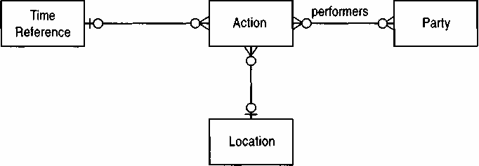

图 8.1 动作的属性。

Figure 8.1 Properties of actions.

在制定和监控计划时，我们必须考虑一项行动可能经历的多种状态。它可以被安排、分配资源、配备人员、启动和完成。状态转换图可以记录这些状态以及转换的发生方式。很难对这些转换制定任何规则。安排行动和分配资源显然可以按任意顺序进行。表面分析可能会得出结论：行动不能在资源分配和安排之前启动。那么，我们该如何处理在正式确定行动时间之前就已经启动的行动呢？我们可以辩称，这类行动是在启动前不久才被安排的，但这听起来更像是管理理论的合理化解释，而不是对实际业务流程的反映。另一个问题是部分资源分配。任何项目经理都会告诉你，在现实世界中，任务经常在所有必需资源分配完毕之前就开始了。我们如何在行动状态的描述中反映这种情况呢？

When making and monitoring plans, we must consider the many states that an action can go through. It can be scheduled, resourced, peopled, started, and completed. A state-transition diagram can record these states and how the transitions can occur. It is difficult to make any rules about these transitions. Scheduling an action and resourcing it can clearly happen in any order. A surface analysis may conclude that an action cannot be started before resourcing and scheduling. How do we deal with actions that are started before any formal decision is made to state a time for them? We could argue that such actions are scheduled a moment before they are started, but this sounds more like a management theory rationalization than a reflection of the real business process. Another problem arises with partial resourcing. Any project manager will tell you that in the real world, tasks are often begun before all the required resources are allocated. How can we reflect this situation in descriptions of action states?

如图 8.2 所示，行动的两个重要状态是提议行动和已实施行动。提议行动仅仅是计划中的一个提案。因此，可以通过添加时间参考点来安排行动进度，通过添加参与方来获取资源，并指定相应的位置。这些更改可以随时按任意顺序进行。一旦行动开始，它就进入了实施阶段。这不仅改变了行动状态，而且还会创建一个单独的已实施行动对象。这使我们能够记录计划与实施之间的差异。通过保留原始的提议行动，我们可以看到计划与实际情况之间的差异。例如，一个常见的差异是时间参考点；然而，随着计划文档最终转化为行动，任何属性都可能发生改变。

The two important states of action are proposed and implemented actions, as shown in Figure 8.2. A proposed action is purely a proposal that exists in some plan. As such it can be scheduled by adding a time reference, resourced by adding parties, and located with the appropriate location. These changes can be made at any time, in any order. Once an action is begun, it is implemented. Not only is this a change in state, but also a separate implemented action object is created. This allows us to record differences between plan and implementation. By retaining the original proposed action, we can see the differences between the plan and reality. A common difference, for example, is the time reference; however, any attribute can change as planning documents finally turn into actions.

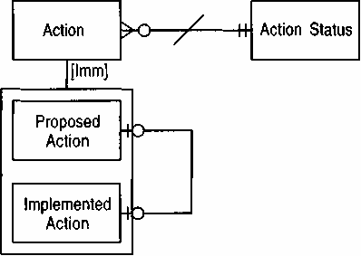

图 8.2 计划和行动的基本结构。

Figure 8.2 Basic structure of plans and actions.

将提案和实施方案分别记录在不同的文件中，以便 跟踪差异。

Separate objects record the proposal and the implementation so that differences can be tracked.

例如，我决定在 1997 年 7 月 1 日为 OOPSLA 准备一个演示文稿，但我直到 7 月 3 日才开始着手准备。这些行动可以表示为一个日期为 7 月 1 日的提议行动和一个日期为 7 月 3 日的已实施行动。提议的所有其他属性均相同。

Example I decide to prepare a presentation for OOPSLA on July 1, 1997, but I don't get around to doing it until the 3rd. These actions can be represented as a proposed action with a date of July 1 and an implemented action with a date of July 3. All other attributes of the proposal are the same.

我们可以提供一个派生的动作状态属性，以便更轻松地判断一个动作所处的状态，而无需遍历记录其状态的各种结构。虽然在现阶段这并非必要，但随着我们后续考虑其他结构，它的价值将日益凸显。

We can provide a derived action state property to make it easier to tell what state an action is in without navigating the various structures that record its state. This is not really necessary at this stage but becomes valuable as we consider additional structures later.

为了在记录日常行动时保持最大的灵活性，如图 8.2 所示，计划行动与已实施行动之间的关联是可选的。很多时候，即使是最好的计划也会因为缺乏执行而束之高阁，许多行动甚至在没有任何事先计划的情况下发生。我们应该抵制为临时计划寻找合理性的诱惑。

To retain the best degree of flexibility in recording daily actions, the links between proposed action and implemented action, as shown in Figure 8.2, are optional. Often the best laid plans gather dust without implementation, and many actions occur without any prior planning. We should resist the temptation to rationalize last-minute plans.

例如，瑟兹医生为约翰·史密斯开了全血细胞计数检查单，但病人没有来做检查。这代表一项已提出的行动，但尚未实施。如果病人被重新预约到稍后的日期，这就构成了一项新的已提出的行动。

Example Doctor Thursz orders a full blood count for John Smith, but the patient does not turn up for the test. This represents a proposed action without an implemented action. If the patient is rebooked for a later date, this constitutes a new proposed action.

例如，凯恩斯医生被叫去诊治一位在火车上突然生病的女士。这里已经采取了行动，但没有提出行动方案。

Example Doctor Cairns is called to attend a woman who is taken suddenly ill on a train. Here there is an implemented action but no proposed action.